# Projet économétrie

Déterminants socio-économiques, familiaux et environnementaux de la mortalité infantile à l’échelle départementale en France

Louise Albarran et Eloïse Sibottier

2025-12-12

Ce mémoire a été rédigé avec l’aide d’outils d’intelligence artificielle, qui ont servi à faciliter la rédaction et à l’optimisation du code, tout en laissant l’analyse, les choix méthodologiques et l’interprétation des résultats à l’initiative des auteures.

# **1 Introduction**

## 1.1) Contexte et problématique

La mortalité infantile constitue un indicateur central de l’état de santé d’une population et, plus largement, du niveau de développement socio-économique d’un territoire. En dépit d’un système de santé parmi les plus performants en moyenne, la France présente des disparités territoriales marquées en matière de mortalité infantile, observables à l’échelle départementale. Ces écarts interrogent la capacité des politiques publiques à garantir une égalité réelle face aux conditions de naissance et de survie des enfants sur l’ensemble du territoire dans un contexte d’amplification des déserts médicaux et de fermetures massives de maternités.

La mortalité infantile désigne le nombre de décès d’enfants nés vivants de moins d’un an lors d’une année civile par rapport au nombre de naissances vivantes de la même année, en général, on la mesure en nombre de décès pour 1000 naissances, ce nombre s’élevait à 4 en 2023.

La littérature en économie de la santé souligne que la mortalité infantile ne dépend pas uniquement de facteurs médicaux stricto sensu, mais résulte d’un ensemble complexe de déterminants sociaux, économiques, familiaux et environnementaux. Les conditions de vie des ménages, la structure familiale, l’accès aux services de santé, ainsi que l’exposition à des facteurs environnementaux défavorables jouent un rôle déterminant dans la santé des nouveau-nés. Toutefois, ces déterminants sont fortement interdépendants et varient considérablement selon les territoires, rendant leur analyse empirique particulièrement délicate.

Dans ce contexte, l’analyse des disparités départementales de mortalité infantile en France soulève une question centrale : dans quelle mesure les inégalités socio-économiques, familiales et environnementales contribuent-elles à expliquer les écarts observés de mortalité infantile entre les départements ?

## 1.2) Motivation et intérêt du sujet

L’intérêt de ce travail est double. D’un point de vue empirique, il s’inscrit dans une volonté de mieux comprendre les mécanismes territoriaux associés à la mortalité infantile en France, à partir de données administratives et statistiques récentes. Alors que de nombreux travaux adoptent une approche macro-internationale ou micro-individuelle, l’échelle départementale permet d’analyser des disparités fines tout en restant pertinente pour l’action publique locale.

D’un point de vue méthodologique, ce projet constitue un terrain d’application privilégié des outils de l’économétrie linéaire. La richesse des données mobilisées, le nombre élevé de variables explicatives potentielles et la présence d’hétérogénéités territoriales marquées imposent une réflexion approfondie sur la spécification du modèle, la gestion de la multicolinéarité et la validité des hypothèses sous-jacentes à l’estimation par moindres carrés ordinaires. Le sujet se prête ainsi particulièrement bien à une démarche économétrique rigoureuse et progressive.

Enfin, ce travail s’inscrit dans une perspective plus large de réflexion sur les inégalités sociales de santé, thème central en économie de la santé et en économie publique, et susceptible d’éclairer les débats relatifs à l’efficacité et au ciblage des politiques sociales et environnementales.

## 1.3) Questions de recherche et hypothèses

À partir de ces éléments, ce projet s’articule autour de la question de recherche suivante :

**Quels sont les principaux déterminants socio-économiques, familiaux et environnementaux de la mortalité infantile à l’échelle départementale en France, et dans quelle mesure leurs effets varient-ils selon les caractéristiques territoriales ?**

Cette question générale se décline en plusieurs hypothèses empiriques :

- **H1 :** Les départements caractérisés par une plus grande précarité socio-économique (pauvreté, dépendance aux prestations sociales, faibles niveaux de diplôme) présentent une mortalité infantile plus élevée.
- **H2 :** La structure familiale, en particulier la part des familles monoparentales, est positivement associée à la mortalité infantile.
- **H3 :** Les facteurs environnementaux, et notamment les émissions de gaz à effet de serre, exercent un effet significatif sur la mortalité infantile.
- **H4 :** Les effets des déterminants socio-économiques ne sont pas homogènes sur l’ensemble du territoire et peuvent varier selon le niveau d’exposition environnementale, traduisant l’existence de mécanismes d’hétérogénéité ou d’effets de seuil.

## 1.4) Objectifs et contributions du projet

L’objectif principal de ce projet est d’identifier empiriquement les déterminants robustes de la mortalité infantile à l’échelle départementale, en mobilisant un cadre économétrique cohérent et rigoureux. Plus précisément, il s’agit :

- d’évaluer l’association entre mortalité infantile et un ensemble de variables socio-économiques, familiales et environnementales ;
- de construire un modèle parcimonieux permettant de limiter les problèmes de multicolinéarité tout en conservant une interprétation économique claire ;
- de tester l’existence d’effets non linéaires et d’hétérogénéités territoriales à travers l’introduction de variables indicatrices et de termes d’interaction ;
- de vérifier la robustesse des résultats aux principales hypothèses du modèle linéaire classique.

La contribution de ce travail est avant tout empirique et méthodologique. Il propose une application détaillée des outils de l’économétrie linéaire à un enjeu de santé publique, tout en mettant en évidence les limites inhérentes à une analyse transversale et en ouvrant des pistes pour des prolongements futurs.

## 1.5) Plan du projet

Dans ce rapport, nous allons présenter le cadre méthodologique de notre projet et le modèle économétrique retenu dans la section 2 avant de procéder à l’analyse des données et à la construction progressive du modèle en section 3. Ensuite, nous analyserons les résultats obtenus ainsi que les tests de robustesse dans la section 4 et récapitulerons les points principaux de ce projet et proposerons des perspectives de recherche dans la conclusion avant de présenter la bibliographie sur laquelle nous nous sommes appuyées et les sources de nos données.

# **2. Cadre méthodologique**

## 2.1) Choix méthodologiques généraux

Afin d’analyser les déterminants de la mortalité infantile à l’échelle départementale, ce projet s’inscrit dans le cadre d’un modèle de régression linéaire estimé par la méthode des moindres carrés ordinaires (MCO). Ce choix s’explique par plusieurs raisons. D’une part, la variable expliquée (le taux de mortalité infantile) est continue et mesurée de manière homogène entre les départements. D’autre part, le cadre linéaire permet une interprétation économique directe des coefficients estimés et constitue une référence standard dans la littérature empirique en économie de la santé.

Le modèle de base peut s’écrire sous la forme suivante :

$Y_i = \beta_0 + \beta_1 X_{1i} + \beta_2 X_{2i} + \dots + \beta_k X_{ki} + \varepsilon_i$,

où $(Y_i)$ désigne le taux de mortalité infantile dans le département $(i)$, $(X_{ji})$ les variables explicatives retenues, $(\beta_j)$ les paramètres à estimer, et $(\varepsilon_i)$ un terme d’erreur capturant l’ensemble des facteurs non observés.

## 2.2) Justification des choix techniques et des stratégies d’estimation

La stratégie d’estimation adoptée repose sur une démarche progressive et exploratoire, adaptée à la richesse des données disponibles et au nombre élevé de variables explicatives candidates. Dans un premier temps, une analyse descriptive approfondie est menée afin d’identifier les distributions des variables, la présence d’outliers et les éventuelles asymétries. Cette étape motive l’application de transformations logarithmiques sur certaines variables afin de réduire l’influence des valeurs extrêmes et de se rapprocher des hypothèses de linéarité et d’homoscedasticité requises par le modèle MCO.

Dans un second temps, une attention particulière est portée à la gestion de la multicolinéarité, phénomène fréquent dans l’analyse de données territoriales. Plusieurs outils complémentaires sont mobilisés : l’analyse des corrélations bivariées, la règle de Klein et le calcul des facteurs d’inflation de la variance (VIF). Ces diagnostics permettent d’identifier les redondances informationnelles entre variables et de guider la réduction progressive du modèle.

La sélection du modèle final repose sur une combinaison de critères statistiques et économiques. Des procédures de sélection automatique fondées sur le critère d’information d’Akaike (AIC) (forward, backward et stepwise) sont utilisées afin d’identifier les spécifications les plus informatives. Ces résultats sont ensuite confrontés à la cohérence des signes des coefficients et aux intuitions issues de la littérature économique, afin d’éviter une sélection purement mécanique guidée uniquement par les données.

Enfin, afin de prendre en compte d’éventuelles non-linéarités et hétérogénéités territoriales, des variables indicatrices et des termes d’interaction sont introduits dans certaines spécifications. Cette approche permet de tester l’existence d’effets de seuil et de différences structurelles entre groupes de départements, notamment selon leur niveau d’exposition environnementale.

La validité des résultats est évaluée à l’aide d’un ensemble complet de diagnostics du modèle MCO : analyse des résidus, identification des observations influentes, tests de normalité et d’homoscedasticité. Lorsque cela est nécessaire, des erreurs-types robustes sont mobilisées afin de sécuriser l’inférence statistique.

L’ensemble de cette démarche vise à construire un modèle économétrique à la fois rigoureux sur le plan statistique et interprétable sur le plan économique, tout en reconnaissant les limites inhérentes à une analyse transversale et non causale.

# **3 Analyse des données**

## **3.1 Cadre des données**

La variable que nous cherchons expliqué est la mortalité infantile

| Code | Définition synthétique | Unité | Source |
| --- | --- | --- | --- |
| **Mort_inf** | Taux de mortalité infantile (décès d’enfants de moins d’un an rapportés aux naissances vivantes, moyenne 2021–2023) | ‰ (pour 1 000) | INSEE – État civil |

La mortalité infantile est un indicateur clé de la santé et du bien‑être des populations. Son analyse nécessite de prendre en compte un ensemble de facteurs socio‑économiques, familiaux et environnementaux. Pour mieux comprendre les déterminants de la mortalité infantile, nous avons regroupé les variables explicatives en trois grandes catégories : précarité et vulnérabilités socio‑économiques, structure familiale et professionnelle, et accès au logement, aux services localisés et à l’environnement. Cette classification permet de mettre en évidence les différentes dimensions qui peuvent influencer la santé des enfants avant un an.

### Catégorie 1 : Précarité et vulnérabilités socio-économiques :

La première dimension étudiée concerne les facteurs socio‑économiques, qui reflètent la vulnérabilité des ménages et leur exposition à la pauvreté.

| Code | Définition synthétique | Unité | Source |
| --- | --- | --- | --- |
| **tx_chom** | Taux de chômage annuel moyen (15–64 ans, 2022) | % | INSEE – RP |
| **Tx_pauvrete** | Taux de pauvreté (2021) | % | INSEE – Filosofi |
| **Pas_diplo** | Part des non ou peu diplômés (15 ans ou plus, non scolarisés, 2022) | % | INSEE – RP |
| **Part_RSA** | Allocataires du RSA pour 1 000 habitants (15–64 ans, 2021) | ‰ | CNAF – FILEAS |
| **Part_ALF** | Part des bénéficiaires de l’allocation logement familiale (2021) | % | CNAF – BENTRIM/FILEAS |
| **tx_pauv_monoparentales** | Taux de pauvreté des familles monoparentales (2021) | % | INSEE – Filosofi |
| **Prest_fami** | Part des prestations familiales dans le revenu disponible (2021) | % | INSEE – Filosofi |

### Catégorie 2 : Structure familiale et structure professionnelle

Au-delà de la précarité, la composition familiale et la structure professionnelle jouent un rôle déterminant. La taille des familles, le nombre de familles monoparentales, le niveau de vie médian et la répartition des catégories professionnelles peuvent affecter les conditions de vie et la capacité des familles à prendre soin de leurs enfants.

| Code | Définition synthétique | Unité | Source |
| --- | --- | --- | --- |
| **monoparentales** | Part des familles monoparentales (2022) | % | INSEE – RP |
| **trois_enfants** | Part des familles avec trois enfants ou plus (2022) | % | INSEE – RP |
| **Med_niv_vie** | Niveau de vie médian (2021) | € | INSEE – Filosofi |
| **part_ouvrier** | Part des ouvriers dans les emplois au lieu de travail (2022) | % | INSEE – RP |
| **part_cadre** | Part des cadres et professions intellectuelles supérieures (2022) | % | INSEE – RP |

### Catégorie 3 : Accès au logement, services localisés et environnement

Enfin, l’accès aux services, au logement et l’exposition à l’environnement constituent la troisième dimension. La proximité des professionnels de santé, la densité de population, l’exposition aux gaz à effet de serre et la présence de fonctionnaires territoriaux sont autant de facteurs qui peuvent moduler les conditions de santé des enfants et, par conséquent, leur survie.

| Code | Définition synthétique | Unité | Source |
| --- | --- | --- | --- |
| **APL_gene** | Accessibilité potentielle localisée aux médecins généralistes (2023) | consultations accessibles / habitant | DREES – SNIIR-AM |
| **APL_sages_femmes** | Accessibilité potentielle localisée aux sages-femmes (2023) | ETP / 100 000 habitants | DREES – SNIIR-AM |
| **Part_pop_eloignee** | Part de la population éloignée des services de soins (> 20 minutes, 2023) | % | Obs. Territoires – BPE |
| **Dens_pop** | Densité de population (2022) | hab./km² | INSEE – RP |
| **Gaz_effet_serre** | Émissions de gaz à effet de serre par habitant (2021) | tonnes de CO₂ / habitant | Citepa |
| **Eff_fonc_publique_terr** | Effectif de la fonction publique territoriale pour 1 000 habitants (2023) | ‰ | INSEE – SIASP |

## **3.2 Prétraitement et nettoyage des données**

Les données initialement collectées présentent une forte hétérogénéité et un nombre élevé de variables, ce qui rend leur exploitation directe peu lisible. Afin de structurer l’analyse et de faciliter l’interprétation des résultats, les variables ont été regroupées en trois ensembles thématiques : la précarité et les vulnérabilités socio-économiques, la structure familiale et professionnelle, et enfin l’accès au logement, aux services et à l’environnement. Cette classification permet d’organiser les statistiques descriptives autour de dimensions cohérentes et directement liées aux mécanismes étudiés.

La gestion des valeurs manquantes constitue une difficulté importante, en particulier pour les territoires ultramarins. L’ampleur des données manquantes a conduit à l’exclusion de la majorité de ces territoires du champ de l’étude. Néanmoins, les bases relatives à La Réunion et à la Martinique étant suffisamment renseignées, ces deux départements ont été conservés, ce qui permet de maintenir une représentation partielle des dynamiques ultramarines sans dégrader la qualité des estimations.

Certaines variables ont également été transformées afin d’en améliorer la lisibilité et l’usage économétrique. Le taux de bénéficiaires du RSA, initialement exprimé en pour mille, a été converti en pourcentage afin de faciliter son interprétation. Les effectifs de la fonction publique ont été rapportés à la population départementale, ce qui permet d’obtenir des indicateurs comparables entre départements, exprimés en pour mille.

Ces choix méthodologiques visent à garantir la rigueur et la lisibilité de notre analyse, tout en assurant que les données utilisées soient à la fois complètes et comparables.

**Code pour le chargement des données**

```r
# ==============================================================================
# CHARGEMENT ET PRÉPARATION DES DONNÉES
# ==============================================================================

# Chargement des données brutes
donnees_brutes <- read_excel("./data/data_final.xlsx")

# Variable à expliquer
var_dependante <- "Mort_inf"

# Liste complète des variables explicatives candidates
variables_explicatives_completes <- c(
  # Précarité et vulnérabilités socio-économiques
  "tx_chom", "Tx_pauvrete", "Pas_diplo", "Part_RSA", "Part_ALF",
  "tx_pauv_monoparentales", "Prest_fami",

  # Structure familiale et professionnelle
  "monoparentales", "trois_enfants", "Med_niv_vie", "part_ouvrier", "part_cadre",

  # Accès aux services et environnement
  "APL_gene", "APL_sages_femmes", "Part_pop_eloignee", "Dens_pop",
  "Gaz_effet_serre", "Eff_fonc_publique_terr",

  # Variable supplémentaire
  "part_cadre_ind"
)
```

## **3.3 Analyse descriptive univariée des données**

L’analyse univariée a été réalisée par catégorie pour examiner la distribution de chaque variable (histogrammes), permettant ainsi de détecter d’éventuels problèmes de distribution, d’hétéroscédasticité ou la présence d’outliers.

**Code pour les définitions des catégories et des labels**

```r
# ==============================================================================
# DÉFINITION DES CATÉGORIES ET LABELS
# ==============================================================================

# Catégorie 1 : Précarité et vulnérabilités socio-économiques
categorie_precarite <- c(
  "tx_chom", "Tx_pauvrete", "Pas_diplo", "Part_RSA", "Part_ALF",
  "tx_pauv_monoparentales", "Prest_fami"
)

# Catégorie 2 : Structure familiale et professionnelle
categorie_structure <- c(
  "monoparentales", "trois_enfants", "Med_niv_vie", "part_ouvrier", "part_cadre"
)

# Catégorie 3 : Accès aux services et environnement
categorie_acces_env <- c(
  "APL_gene", "APL_sages_femmes", "Part_pop_eloignee", "Dens_pop",
  "Gaz_effet_serre", "Eff_fonc_publique_terr"
)

# Labels descriptifs pour toutes les variables
labels_variables <- c(
  # Variable dépendante
  Mort_inf = "Mortalité infantile",

  # Précarité
  tx_chom = "Taux de chômage",
  Tx_pauvrete = "Taux de pauvreté",
  Pas_diplo = "Part sans diplôme",
  Part_RSA = "Part des bénéficiaires du RSA",
  Part_ALF = "Part des bénéficiaires ALF",
  tx_pauv_monoparentales = "Taux pauvreté des monoparentales",
  Prest_fami = "Prestations familiales",

  # Structure familiale et professionnelle
  monoparentales = "Part familles monoparentales",
  trois_enfants = "Familles avec 3 enfants ou plus",
  Med_niv_vie = "Niveau de vie médian",
  part_ouvrier = "Part des ouvriers",
  part_cadre = "Part des cadres",
  part_cadre_ind = "Part des cadres ind",

  # Accès et environnement
  APL_gene = "APL généraliste",
  APL_sages_femmes = "APL sages-femmes",
  Part_pop_eloignee = "Population éloignée des services",
  Dens_pop = "Densité de population",
  Gaz_effet_serre = "Emissions de GES",
  Eff_fonc_publique_terr = "Effectifs fonction publique territoriale"
)
```

**Code pour la fonctions des tableaux descriptifs**

```r
# ==============================================================================
# FONCTION POUR TABLEAUX DESCRIPTIFS
# ==============================================================================

creer_tableau_descriptif <- function(data, variables, titre, labels) {
  datasummary(
    formula = as.formula(
      paste(paste(variables, collapse = " + "),
            "~ Mean + SD + Min + Median + Max")
    ),
    data = data,
    title = titre,
    statistic = c(
      Mean = "mean",
      SD = "sd",
      Min = "min",
      Median = "median",
      Max = "max"
    ),
    labels = labels,
    output = "markdown"
  )
}
```

**Précarité et vulnérabilités socio-économiques**

| Variable | Mean | SD | Min | Median | Max |
| --- | --- | --- | --- | --- | --- |
| Taux de chômage | 7.71 | 1.87 | 4.30 | 7.35 | 18.00 |
| Taux de pauvreté | 15.22 | 3.88 | 9.10 | 14.85 | 36.10 |
| Part sans diplôme | 20.63 | 3.68 | 11.50 | 20.65 | 34.90 |
| Part des bénéficiaires du RSA | 4.25 | 2.17 | 1.70 | 3.83 | 17.33 |
| Part des bénéficiaires ALF | 9.99 | 4.14 | 4.40 | 9.80 | 32.90 |
| Taux pauvreté des monoparentales | 30.41 | 4.86 | 19.70 | 29.70 | 53.90 |
| Prestations familiales | 1.90 | 0.43 | 0.70 | 1.90 | 4.10 |

Figure 1 : Statistiques descriptives pour la précarité et vulnérabilités socio-économiques

**Structure familiale et professionnelle**

| Variable | Mean | SD | Min | Median | Max |
| --- | --- | --- | --- | --- | --- |
| Part familles monoparentales | 16.28 | 4.08 | 10.30 | 15.35 | 42.80 |
| Familles avec 3 enfants ou plus | 8.01 | 2.20 | 4.50 | 7.60 | 17.30 |
| Niveau de vie médian | 22619.18 | 1820.03 | 17070.00 | 22230.00 | 29730.00 |
| Part des ouvriers | 21.67 | 4.32 | 7.30 | 21.50 | 29.90 |
| Part des cadres | 15.17 | 6.27 | 9.30 | 13.15 | 47.70 |

Figure 2 : Statistiques descriptives pour la structure familiale et professionnelle

**Accès au logement, services localisés et environnement**

| Variable | Mean | SD | Min | Median | Max |
| --- | --- | --- | --- | --- | --- |
| APL généraliste | 3.15 | 0.66 | 2.00 | 3.00 | 4.70 |
| APL sages-femmes | 21.67 | 5.03 | 9.90 | 22.20 | 38.10 |
| Population éloignée des services | 1.77 | 2.89 | 0.00 | 0.70 | 19.10 |
| Densité de population | 561.95 | 2375.89 | 14.80 | 86.05 | 20054.10 |
| Emissions de GES | 6.86 | 2.46 | 2.19 | 6.40 | 16.94 |
| Effectifs fonction publique territoriale | 29.92 | 5.51 | 19.22 | 29.04 | 56.61 |

Figure 3 : Statistiques descriptives pour l’accès au logement, aux services localisés et environnement

En examinant le résumé des données, certains résultats attire notre attention et montrent des situations très extrêmes pour plusieurs variables. Par exemple :

- La part de population éloignée des services atteint 19% à Lorèze, alors que le troisième quartile n’est que de 1,75%. (Figure 3)
- La part des bénéficiaires du RSA culmine à 17,33% à La Réunion contre 4,66% pour le troisième quartile. (Figure 1)
- La part des bénéficiaires ALF est de 32% à La Réunion, alors que Q3 = 11,45%.(Figure 1)
- La part des cadres atteint 47,70% dans les Hauts-de-Seine, contre 16,40% pour Q3. (Figure 2)
- La part des familles monoparentales atteint 42,80% en Martinique, contre 17% pour Q3. (Figure 2)
- Enfin, la densité de population présente une forte hétéroscédasticité, avec des valeurs très variables entre départements. (Figure 3)

Ces observations mettent en évidence la présence de valeurs extrêmes qui pourraient avoir un poids disproportionné dans l’analyse. Elles suggèrent que certaines variables pourraient bénéficier d’une transformation logarithmique pour plusieurs raisons :

- **Réduire l’impact des outliers :** les individus atypiques sont « compressés », ce qui limite leur influence excessive sur les modèles de régression.
- **Resserer les distributions :** les variables très asymétriques deviennent plus homogènes et plus proches d’une forme symétrique.
- **Améliorer la robustesse des estimations :** la linéarité et l’homoscédasticité sont mieux respectées, ce qui rend les résultats des modèles multivariés plus fiables.

Cette première observation justifie donc de considérer un passage en logarithme pour plusieurs variables, mais la décision finale sera confirmée avec la suite de notre analyse descriptive, afin de vérifier que la transformation améliore réellement la structure des données et la qualité des modèles.

### 3.3.1 Précarité et vulnérabilités socio-économiques

**Code pour la créations des histrogrammes**

```r
# ==============================================================================
# ANALYSE DESCRIPTIVE : HISTOGRAMMES PAR CATÉGORIE
# ==============================================================================

# Fonction pour créer des histogrammes
creer_histogrammes <- function(data, variables, couleur, labels) {
  lapply(variables, function(var) {
    ggplot(data, aes_string(x = var)) +
      geom_histogram(fill = couleur, color = "black", bins = 15) +
      ggtitle(labels[var]) +
      xlab(labels[var]) +
      ylab("Effectif") +
      theme_minimal()
  })
}
```

**Code pour l’histogrammes catégorie 1 : Précarité et vulnérabilités socio-économiques**

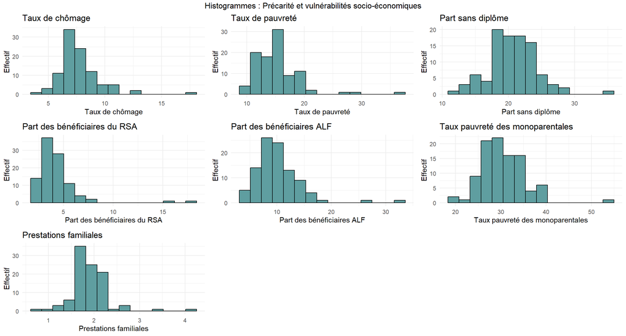

Figure 4 : Histogrammes des variables sur la récarité et vulnérabilités socio-économiques

```r
# Histogrammes catégorie 1 : Précarité
histos_precarite <- creer_histogrammes(
  donnees_brutes,
  categorie_precarite,
  "cadetblue",
  labels_variables
)
do.call(grid.arrange, c(
  histos_precarite,
  ncol = 3,
  top = "Histogrammes : Précarité et vulnérabilités socio-économiques"
))
```

### 3.3.2 Structure familiale et structure professionnelle

Dans la catégorie « structure familiale et professionnelle », les histogrammes (Figure 5) confirment aussi la domination d’outliers à droite pour la plupart des variables, à l’exception notable de la part des ouvriers qui présente une répartition beaucoup plus homogène et moins « extrême ».

La part des familles monoparentales et le niveau de vie médian sont quant à eux fortement concentrés autour d’une valeur centrale, montrant une leptokurticité : forte concentration autour de la moyenne et queues relativement fines. Ces observations indiquent que la plupart des départements sont assez proches les uns des autres pour certaines mesures, mais quelques-uns se distinguent par des valeurs beaucoup plus élevées ou plus faibles.

**Code pour l’histogrammes catégorie 2 : Structure familiale et professionnelle**

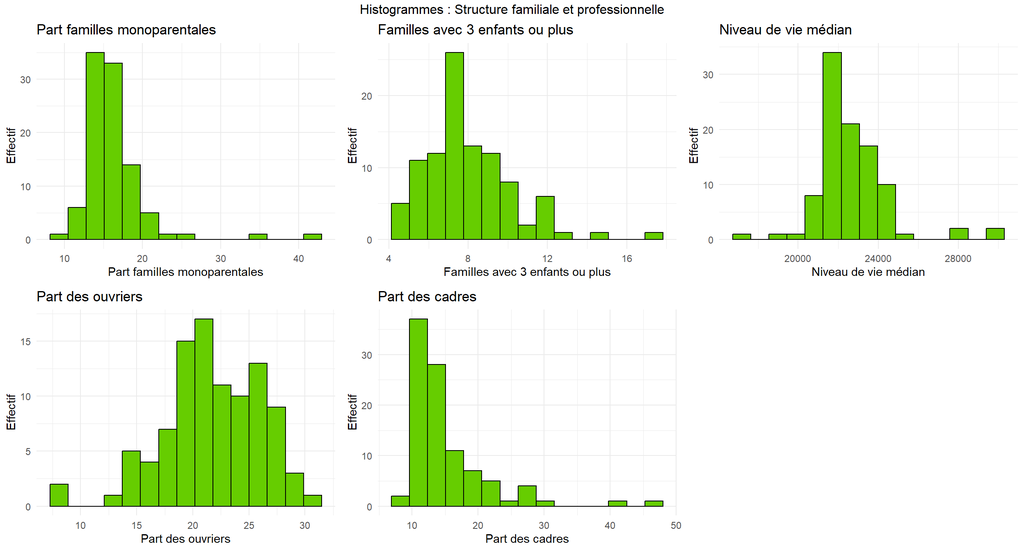

Figure 5 : Histogrammes des variables sur la structure familiale et la structure professionnelle

```r
# Histogrammes catégorie 2 : Structure familiale
histos_structure <- creer_histogrammes(
  donnees_brutes,
  categorie_structure,
  "chartreuse3",
  labels_variables
)
do.call(grid.arrange, c(
  histos_structure,
  ncol = 3,
  top = "Histogrammes : Structure familiale et professionnelle"
))
```

### 3.3.3 Accès au logement, services localisés et environnement

Pour la troisième catégorie « accès au logement, services localisés et environnement », les histogrammes (Figure 6) offrent un panorama hétérogène.

La variable APL généraliste ne révèle pas d’outliers marqués mais sa distribution est manifestement non gaussienne, avec une forme irrégulière et des amas de valeurs sur certaines plages ; elle reste donc incompatible avec l’hypothèse de normalité.

La proportion de population éloignée des services (>20 minutes) est fortement concentrée sur des petites valeurs mais présente un outlier très marqué à droite, ce qui crée une queue asymétrique importante.

La densité de population est massivement concentrée à gauche (beaucoup de départements faiblement denses) et ponctuée par quelques territoires très denses qui forment une longue queue droite ; ce profil est typique des variables géographiques et confirme la nécessité d’un traitement particulier (passage en log)

Enfin, les émissions de gaz à effet de serre et les effectifs de la fonction publique territoriale ont des histogrammes qui s’apparentent davantage à une forme proche d’une distribution « raisonnablement centrée », mais la normalité n’est pas parfaite : ces deux variables restent seulement relativement plus régulières que les autres, sans pouvoir être considérées comme strictement gaussiennes.

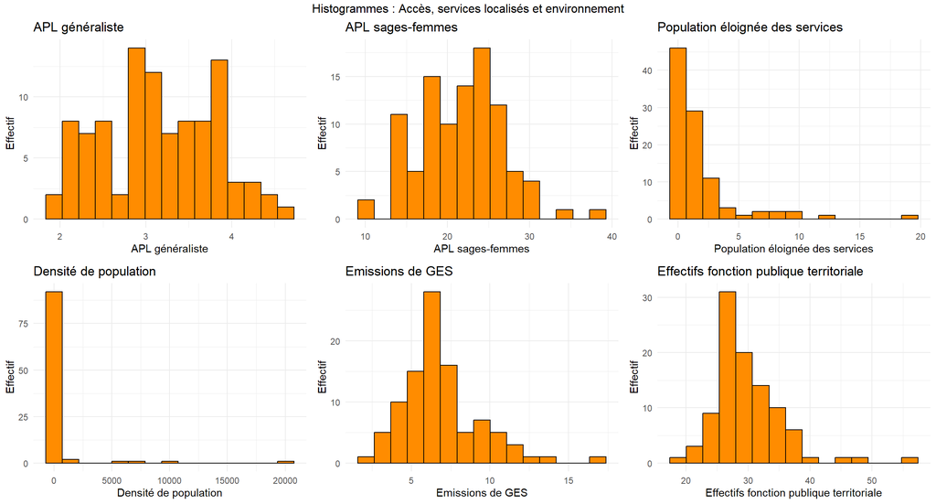

Figure 6 : Histogrammes des variables sur l’accès au logement, les services localisés et l’environnement

```r
# Histogrammes catégorie 3 : Accès et environnement
histos_acces_env <- creer_histogrammes(
  donnees_brutes,
  categorie_acces_env,
  "darkorange",
  labels_variables
)
do.call(grid.arrange, c(
  histos_acces_env,
  ncol = 3,
  top = "Histogrammes : Accès, services localisés et environnement"
))
```

## **3.4 Analyse descriptive bivariée des données**

### 3.4.1 Corrélation entre la variables à expliqués et les variables explicatives

L’analyse bivariée a pour objectif d’évaluer la corrélation linéaire entre la variable dépendante ($Y$: Taux de mortalité infantile) et chacune des variables explicatives ($X$).

**Code des calculs des corrélations et du graphique**

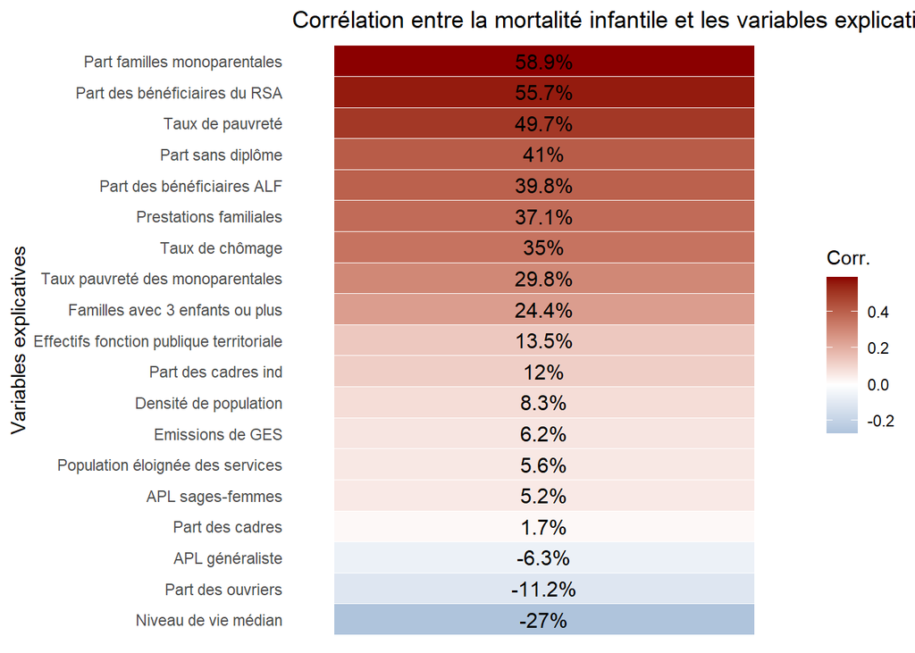

Figure 7: Corrélation entre la mortalité infantile et les variables explicatives

```r
# ==============================================================================
# ANALYSE BIVARIÉE : CORRÉLATIONS
# ==============================================================================

# Calcul des corrélations avec la variable dépendante
correlations_y <- cor(
  donnees_brutes[, variables_explicatives_completes],
  donnees_brutes[[var_dependante]],
  use = "complete.obs"
)

# Création du dataframe pour le graphique
df_correlations <- data.frame(
  Variable = labels_variables[variables_explicatives_completes],
  Correlation = correlations_y,
  Pourcentage = round(correlations_y * 100, 1)
) %>%
  arrange(desc(Correlation))

# Graphique de corrélation
ggplot(df_correlations, aes(x = "", y = reorder(Variable, Correlation), fill = Correlation)) +
  geom_tile(color = "white") +
  geom_text(aes(label = paste0(Pourcentage, "%")), size = 4) +
  scale_fill_gradient2(
    low = "steelblue",
    high = "darkred",
    mid = "white",
    midpoint = 0,
    name = "Corr."
  ) +
  labs(
    x = "",
    y = "Variables explicatives",
    title = "Corrélation entre la mortalité infantile et les variables explicatives"
  ) +
  theme_minimal() +
  theme(
    axis.text.x = element_blank(),
    axis.title.x = element_blank(),
    panel.grid = element_blank()
  )
```

Les corrélations les plus fortes sont observées avec les variables liées à la précarité et à la structure familiale, notamment la Part des familles monoparentales (58.9%) et la Part des bénéficiaires du RSA (55.7%) (Figure 7). Les nuages de points confirment graphiquement ces relations.

#### A) Précarité et vulnérabilités socio-économiques

L’analyse des nuages de points de la première catégorie (Figure 8) fait apparaître des relations clairement linéaires et positives entre la mortalité infantile et l’ensemble des indicateurs de précarité.

Plus le taux de pauvreté, la part des bénéficiaires du RSA, la part sans diplôme ou encore le taux de pauvreté des familles monoparentales augmentent, plus la mortalité infantile tend à s’élever.

Toutefois, la présence d’outliers, souvent situés très à droite du nuage, vient perturber l’ajustement linéaire : ces observations extrêmes peuvent accentuer artificiellement la pente et doivent être prises en compte avec prudence lors de l’interprétation. Malgré ces valeurs atypiques, nous pouvons émettre l’hypothèse que la précarité économique et sociale est fortement associée à une hausse de la mortalité infantile.

```r
# ==============================================================================
# ANALYSE BIVARIÉE : NUAGES DE POINTS PAR CATÉGORIE
# ==============================================================================

# Fonction pour créer des nuages de points
creer_nuages_points <- function(data, variables, var_y, couleur, labels) {
  lapply(variables, function(var) {
    ggplot(data, aes_string(x = var, y = var_y)) +
      geom_point(color = couleur) +
      geom_smooth(method = "lm", se = FALSE, color = "red") +
      ggtitle(paste(labels[var_y], "vs", labels[var])) +
      xlab(labels[var]) +
      ylab(labels[var_y]) +
      theme_minimal()
  })
}
```

**Code pour le nuage de point de la catégorie 1 : Précarité et vulnérabilités**

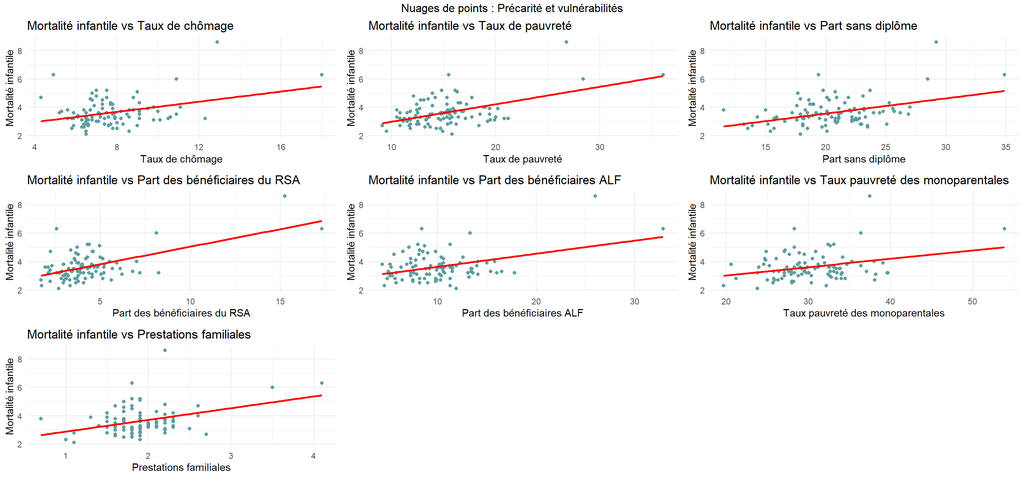

Figure 8 : Nuages de points des variables sur la récarité et vulnérabilités socio-économiques

```r
# Nuages de points catégorie 1 : Précarité
nuages_precarite <- creer_nuages_points(
  donnees_brutes,
  categorie_precarite,
  var_dependante,
  "cadetblue",
  labels_variables
)
do.call(grid.arrange, c(
  nuages_precarite,
  ncol = 3,
  top = "Nuages de points : Précarité et vulnérabilités"
))
```

#### B) Structure familiale et structure professionnelle

La seconde catégorie présente un comportement plus nuancé (Figure 9). Certaines variables y montrent des relations très fortes, d’autres beaucoup plus faibles.

La part des familles monoparentales est celle qui se distingue le plus clairement : son nuage de points laisse apparaître une relation positive nette, ce qui est cohérent avec le fait qu’il s’agit de la variable présentant la corrélation la plus élevée avec la mortalité infantile. Là encore, quelques outliers influencent la pente, notamment des départements ultra-marins ou à structure familiale très particulière, mais la tendance globale reste solide.

La part des familles avec trois enfants ou plus semble elle aussi liée positivement à la mortalité infantile, même si l’effet est visuellement plus faible et plus diffus.

À l’inverse, le niveau de vie médian montre une relation légèrement négative : les départements plus aisés tendent à connaître une mortalité infantile plus faible, ce qui est intuitif, même si la pente demeure modérée.

Un résultat surprenant apparaît pour la part des ouvriers : la relation avec la mortalité infantile est faible, mais elle est négative, ce qui est contre‑intuitif. Alors que l’on observe généralement que les situations socio‑économiques défavorables sont associées à une mortalité infantile plus élevée, ici, les départements avec une part plus importante d’ouvriers semblent légèrement avoir une mortalité infantile plus faible. Cette observation est difficile à expliquer.

Enfin, la part des cadres ne laisse apparaître pratiquement aucune relation visuelle avec la mortalité infantile : le nuage est dispersé, sans tendance nette, ce qui indique que cette variable n’exerce pas d’influence directe identifiable dans ce cadre purement bivarié.

**Code pour le nuage de point de la catégorie 2 : Structure familiale et professionnelle**

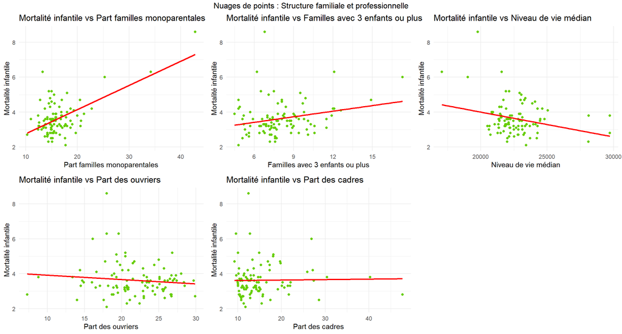

```r
# Nuages de points catégorie 2 : Structure familiale
nuages_structure <- creer_nuages_points(
  donnees_brutes,
  categorie_structure,
  var_dependante,
  "chartreuse3",
  labels_variables
)
do.call(grid.arrange, c(
  nuages_structure,
  ncol = 3,
  top = "Nuages de points : Structure familiale et professionnelle"
))
```

#### C) Accès au logement, services localisés et environnement

La troisième catégorie, regroupant l’accès aux services, des indicateurs d’environnement et des mesures territoriales, est de loin celle qui présente les relations les plus faibles avec la mortalité infantile (Figure 10). La plupart des nuages de points sont largement dispersés, sans forme particulière ni pente identifiable.

Les variables comme l’APL généraliste, l’APL sages-femmes ou la population éloignée des services ne montrent presque aucune structure linéaire : les points sont répartis de manière diffuse, ce qui suggère une absence de relation directe.

Quelques éléments se détachent néanmoins légèrement : la densité de population semble présenter une pente positive faible, indiquant que la mortalité infantile pourrait être un peu plus élevée dans les territoires très denses, mais l’effet reste visuellement très limité.

De manière surprenante, les effectifs de la fonction publique territoriale par 1000 habitants montrent une légère relation positive avec la mortalité infantile : plus il y a de fonctionnaires par habitant, plus la mortalité infantile semble élevée. Ce résultat est contre‑intuitif et ne traduit probablement pas un lien de cause à effet direct, mais pourrait refléter des facteurs confondants liés à la situation sociale ou économique de certains départements.

Dans l’ensemble, les nuages de points confirment que les variables les plus fortement associées à la mortalité infantile appartiennent presque exclusivement au champ socio-économique.

Les structures familiales jouent également un rôle important, mais les variables liées aux services et à l’environnement apparaissent beaucoup moins pertinentes dans leur forme brute. Cette analyse bivariée permet ainsi d’identifier les déterminants les plus robustes avant la construction du modèle multivarié.

**Code pour le nuage de point de la catégorie 3 : Accès, services et environnement**

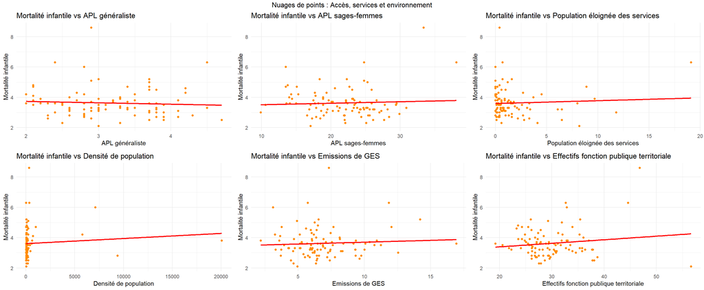

```r
# Nuages de points catégorie 3 : Accès et environnement
nuages_acces_env <- creer_nuages_points(
  donnees_brutes,
  categorie_acces_env,
  var_dependante,
  "darkorange",
  labels_variables
)
do.call(grid.arrange, c(
  nuages_acces_env,
  ncol = 3,
  top = "Nuages de points : Accès, services et environnement"
))
```

### 3.4.2 Transformation des variables : Passage en log

L’analyse préalable des distributions des variables explicatives met en évidence deux caractéristiques récurrentes. D’une part, plusieurs variables présentent une asymétrie marquée à droite, caractérisée par une concentration de la majorité des départements autour de valeurs faibles et par la présence de quelques observations très élevées. D’autre part, certaines variables sont affectées par des valeurs extrêmes susceptibles d’exercer une influence disproportionnée sur les estimations économétriques.

Afin de limiter l’impact de ces phénomènes et de se rapprocher des hypothèses sous-jacentes au modèle linéaire classique, en particulier la linéarité des relations et l’homogénéité de la variance des erreurs, une transformation logarithmique a été appliquée à un sous-ensemble de variables.

Le recours au logarithme présente plusieurs avantages. Il permet tout d’abord de réduire l’influence des valeurs extrêmes en compressant l’échelle des observations élevées, ce qui limite le poids des outliers dans l’estimation des coefficients. Il contribue ensuite à rapprocher la distribution des variables d’une forme plus symétrique, facilitant ainsi le respect de l’hypothèse de normalité des résidus. Enfin, cette transformation améliore la stabilité des estimations dans les modèles multivariés, en particulier lorsque plusieurs variables fortement dispersées sont introduites simultanément.

Les variables ayant fait l’objet d’une transformation logarithmique incluent notamment : la densité de population, la part de la population éloignée des services, la part des bénéficiaires du RSA, la part des bénéficiaires de l’ALF, la part des cadres, ainsi que la part des familles monoparentales.

**Code pour la transformation des variables en logarithme**

```r
# ==============================================================================
# TRANSFORMATIONS LOGARITHMIQUES
# ==============================================================================

# Création d'une copie des données pour les transformations
donnees_transformees <- donnees_brutes

# Application des transformations logarithmiques
donnees_transformees$log_Dens_pop <- log(donnees_brutes$Dens_pop)
donnees_transformees$log_Part_pop_eloignee <- log(donnees_brutes$Part_pop_eloignee + 0.1)
donnees_transformees$log_Part_RSA <- log(donnees_brutes$Part_RSA)
donnees_transformees$log_Part_ALF <- log(donnees_brutes$Part_ALF)
donnees_transformees$log_part_cadre <- log(donnees_brutes$part_cadre)
donnees_transformees$log_monoparentales <- log(donnees_brutes$monoparentales)

# Suppression des variables originales remplacées par leur version log
donnees_transformees <- donnees_transformees %>%
  dplyr::select(-c(
    "Dens_pop", "Part_pop_eloignee", "Part_RSA",
    "Part_ALF", "part_cadre", "monoparentales"
  ))

# Nouvelle liste de variables explicatives avec transformations
variables_transformees <- c(
  # Précarité (certaines transformées)
  "tx_chom", "Tx_pauvrete", "Pas_diplo", "log_Part_RSA", "log_Part_ALF",
  "tx_pauv_monoparentales", "Prest_fami",

  # Structure familiale (certaines transformées)
  "log_monoparentales", "trois_enfants", "Med_niv_vie",
  "part_ouvrier", "log_part_cadre",

  # Accès et environnement (certaines transformées)
  "APL_gene", "APL_sages_femmes", "log_Part_pop_eloignee",
  "log_Dens_pop", "Gaz_effet_serre", "Eff_fonc_publique_terr"
)

# Sélection uniquement des colonnes numériques
donnees_numeriques <- donnees_transformees %>% select_if(is.numeric)
```

## **3.5 Gestion de la Multicolinéarité et Sélection du Modèle**

La construction d’un modèle final économétriquement cohérent repose sur une attention particulière portée aux problèmes de multicolinéarité, fréquents dans les analyses territoriales mobilisant un grand nombre de variables socio-économiques.

Plusieurs critères complémentaires ont été mobilisés conjointement, en s’appuyant exclusivement sur les résultats empiriques issus des estimations :

- l’analyse des corrélations bivariées (seuil critique fixé à |r| > 0,8),
- l’application de la règle de Klein,
- le calcul des facteurs d’inflation de la variance (VIF, avec un seuil critique supérieur à 10),
- ainsi que la cohérence des signes des coefficients estimés avec les relations observées en analyse bivariée.

Ces différents diagnostics ont permis de mettre en œuvre une procédure de réduction progressive du modèle, organisée en trois itérations successives.

### 3.5.1 Itération 1 : Modèle Complet (Reg1)

Le premier modèle (Figure 11) inclut l’ensemble des variables explicatives disponibles, qu’elles soient transformées ou non. Plusieurs variables structurelles, telles que la densité de population, la part de la population éloignée des services, la part des bénéficiaires du RSA, la part des bénéficiaires de l’ALF, la part des cadres et la part des familles monoparentales, sont introduites sous forme logarithmique afin de limiter l’influence des valeurs extrêmes.

**Code pour le premier modèle avec l’ensemble des variables**

```r
# ==============================================================================
# MODÉLISATION : ITÉRATION 1 - MODÈLE COMPLET
# ==============================================================================

# Estimation du modèle complet avec toutes les variables transformées
modele_complet <- lm(Mort_inf ~ ., data = donnees_numeriques)

# Labels pour le tableau de régression du modèle complet
labels_modele_complet <- c(
  tx_chom = "Taux de chômage",
  Med_niv_vie = "Niveau de vie médian",
  Pas_diplo = "Part des personnes sans diplôme",
  log_Dens_pop = "log(densité de population)",
  Tx_pauvrete = "Taux de pauvreté",
  APL_gene = "APL généralistes",
  APL_sages_femmes = "APL sages-femmes",
  log_Part_pop_eloignee = "log(part de population éloignée des services)",
  log_monoparentales = "log(part des familles monoparentales)",
  trois_enfants = "Part des familles avec 3 enfants ou plus",
  tx_pauv_monoparentales = "Taux de pauvreté des familles monoparentales",
  Prest_fami = "Montant des prestations familiales",
  log_Part_RSA = "log(part des bénéficiaires du RSA)",
  log_Part_ALF = "log(part des bénéficiaires de l'ALF)",
  Gaz_effet_serre = "Émissions de gaz à effet de serre",
  Eff_fonc_publique_terr = "Effectifs de la fonction publique territoriale",
  part_ouvrier = "Part des ouvriers",
  log_part_cadre = "log(part des cadres)"
)

summary(modele_complet)
```

```
##
## Call:
## lm(formula = Mort_inf ~ ., data = donnees_numeriques)
##
## Residuals:
##      Min       1Q   Median       3Q      Max
## -1.23491 -0.44119 -0.01823  0.33875  1.99278
##
## Coefficients:
##                          Estimate Std. Error t value Pr(>|t|)
## (Intercept)             3.549e+00  5.699e+00   0.623  0.53525
## tx_chom                -1.519e-01  1.383e-01  -1.098  0.27543
## Prest_fami              6.005e-01  6.396e-01   0.939  0.35070
## Med_niv_vie             6.425e-05  1.589e-04   0.404  0.68707
## Pas_diplo               3.157e-02  6.438e-02   0.490  0.62531
## Tx_pauvrete             3.104e-01  1.071e-01   2.898  0.00488 **
## APL_gene               -9.810e-02  1.709e-01  -0.574  0.56773
## APL_sages_femmes        4.817e-02  1.957e-02   2.461  0.01604 *
## trois_enfants          -7.081e-02  1.247e-01  -0.568  0.57189
## tx_pauv_monoparentales -2.384e-01  7.115e-02  -3.351  0.00124 **
## Gaz_effet_serre         1.005e-01  4.873e-02   2.063  0.04240 *
## Eff_fonc_publique_terr -2.592e-02  1.940e-02  -1.336  0.18552
## part_ouvrier            1.650e-02  6.293e-02   0.262  0.79390
## part_cadre_ind          2.518e-01  3.398e-01   0.741  0.46089
## log_Dens_pop           -3.029e-01  2.143e-01  -1.413  0.16156
## log_Part_pop_eloignee  -2.794e-01  1.354e-01  -2.063  0.04246 *
## log_Part_RSA            1.795e+00  6.521e-01   2.752  0.00736 **
## log_Part_ALF           -7.918e-01  4.986e-01  -1.588  0.11631
## log_part_cadre         -5.856e-01  9.592e-01  -0.610  0.54332
## log_monoparentales      8.220e-01  1.244e+00   0.661  0.51057
## ---
## Signif. codes:  0 '***' 0.001 '**' 0.01 '*' 0.05 '.' 0.1 ' ' 1
##
## Residual standard error: 0.7183 on 78 degrees of freedom
## Multiple R-squared:  0.5501, Adjusted R-squared:  0.4405
## F-statistic: 5.019 on 19 and 78 DF,  p-value: 1.632e-07
```

**Modèle complet avec toutes les variables**

[output not shown]

Figure 11 : Modèle complet avec toutes les variables

L’analyse de la multicolinéarité met immédiatement en évidence la présence de corrélations élevées, principalement concentrées autour des variables de précarité socio-économique. Plusieurs corrélations bivariées dépassent le seuil critique de 80 %, notamment entre la part des bénéficiaires du RSA (log) et le taux de chômage (85,8 %), entre le taux de chômage et le taux de pauvreté (84,8 %), entre le taux de chômage et le taux de pauvreté des familles monoparentales (80,6 %), entre le taux de pauvreté et la pauvreté des familles monoparentales (81,4 %), ainsi qu’entre la densité de population (log) et la part des cadres (log) (84,9 %). Une corrélation élevée est également observée entre la part des cadres (log) et la variable part_cadre_ind (82,2 %).

L’application de la règle de Klein confirme ces constats, plusieurs coefficients de corrélation au carré excédant le R² du modèle complet (0,55). C’est notamment le cas pour les relations impliquant le taux de chômage avec le taux de pauvreté, la pauvreté monoparentale, la part des bénéficiaires du RSA (log) et la part des familles monoparentales (log), ainsi que pour le niveau de vie médian avec l’absence de diplôme et la pauvreté monoparentale. Des schémas similaires sont observées pour la densité de population (log) avec la population éloignée des services (log) et la part des cadres (log), ou encore pour le taux de pauvreté avec la part des bénéficiaires du RSA (log), la part des bénéficiaires de l’ALF (log) et la pauvreté monoparentale.

Les facteurs d’inflation de la variance corroborent l’existence d’une multicolinéarité sévère, avec des valeurs atteignant 32 pour le taux de pauvreté, 22 pour la pauvreté monoparentale, plus de 18 pour la part des cadres (log), plus de 14 pour la variable trois enfants, et plus de 12 pour le taux de chômage. Par ailleurs, certaines variables présentent une incohérence entre le signe attendu à partir des corrélations bivariées et le signe estimé dans le modèle multivarié.

Au regard de l’ensemble de ces éléments, plusieurs variables sont retirées du modèle à ce stade : le taux de chômage, fortement corrélé aux autres indicateurs de précarité et présentant une incohérence de signe ; le niveau de vie médian, redondant avec l’absence de diplôme et la pauvreté monoparentale ; la densité de population (log) et la part des cadres (log), fortement corrélées entre elles ; la part des bénéficiaires du RSA (log), fortement corrélée à la part des familles monoparentales (log) ; ainsi que le taux de pauvreté, caractérisé par un VIF particulièrement élevé. Un second modèle est alors estimé à partir de cet ensemble réduit de variables.

**Code et résultats du diagnostic de multicolinéarité pour l’itération 1**

```r
# ==============================================================================
# MODÉLISATION : ITÉRATION 1 - MODÈLE COMPLET
# ==============================================================================
# --- Diagnostic de multicolinéarité pour le modèle complet ---

# Matrice de corrélation entre variables explicatives
matrice_cor_complet <- cor(
  donnees_transformees[, variables_transformees],
  use = "complete.obs"
)

# Identification des paires avec corrélation > 0.8
indices_forte_cor <- which(
  abs(matrice_cor_complet) > 0.8 & abs(matrice_cor_complet) < 1,
  arr.ind = TRUE
)

if (length(indices_forte_cor[, 1]) > 0) {
  paires_forte_cor <- data.frame(
    Var1 = rownames(matrice_cor_complet)[indices_forte_cor[, 1]],
    Var2 = colnames(matrice_cor_complet)[indices_forte_cor[, 2]],
    Correlation = matrice_cor_complet[indices_forte_cor]
  )
  paires_forte_cor <- paires_forte_cor[paires_forte_cor$Var1 < paires_forte_cor$Var2, ]
  cat("Paires de variables avec corrélation |r| > 0.8 :\n")
  print(paires_forte_cor)
}
```

```
## Paires de variables avec corrélation |r| > 0.8 :
##                      Var1                   Var2 Correlation
## 2            log_Part_RSA                tx_chom   0.8580817
## 4                 tx_chom            Tx_pauvrete   0.8482424
## 5            log_Part_RSA            Tx_pauvrete   0.8520683
## 6  tx_pauv_monoparentales            Tx_pauvrete   0.8142046
## 10                tx_chom tx_pauv_monoparentales   0.8065582
## 12           log_Part_RSA tx_pauv_monoparentales   0.8094010
## 13           log_Dens_pop         log_part_cadre   0.8492169
```

```r
# Test de Klein (R²)
R2_complet <- summary(modele_complet)$r.squared
cat("R² du modèle complet :", round(R2_complet, 3), "\n")
```

```
## R² du modèle complet : 0.55
```

```r
matrice_cor_klein <- cor(
  donnees_numeriques[, setdiff(names(donnees_numeriques), var_dependante)],
  use = "pairwise.complete.obs"
)
indices_klein <- which(
  matrice_cor_klein^2 > R2_complet & matrice_cor_klein^2 < 1,
  arr.ind = TRUE
)

if (length(indices_klein[, 1]) > 0) {
  paires_klein <- unique(t(apply(indices_klein, 1, function(x) sort(x))))
  cat("Paires de variables où r² > R² (test de Klein) :\n")
  for (k in 1:nrow(paires_klein)) {
    i <- paires_klein[k, 1]
    j <- paires_klein[k, 2]
    cat("-", colnames(matrice_cor_klein)[i], "<->", colnames(matrice_cor_klein)[j],
        ": r² =", round(matrice_cor_klein[i, j]^2, 3),
        " (>", round(R2_complet, 3), ")\n")
  }
}
```

```
## Paires de variables où r² > R² (test de Klein) :
## - tx_chom <-> Tx_pauvrete : r² = 0.72  (> 0.55 )
## - tx_chom <-> tx_pauv_monoparentales : r² = 0.651  (> 0.55 )
## - tx_chom <-> log_Part_RSA : r² = 0.736  (> 0.55 )
## - tx_chom <-> log_monoparentales : r² = 0.553  (> 0.55 )
## - Med_niv_vie <-> Pas_diplo : r² = 0.556  (> 0.55 )
## - Med_niv_vie <-> tx_pauv_monoparentales : r² = 0.623  (> 0.55 )
## - Tx_pauvrete <-> tx_pauv_monoparentales : r² = 0.663  (> 0.55 )
## - Tx_pauvrete <-> log_Part_RSA : r² = 0.726  (> 0.55 )
## - Tx_pauvrete <-> log_Part_ALF : r² = 0.604  (> 0.55 )
## - Tx_pauvrete <-> log_monoparentales : r² = 0.59  (> 0.55 )
## - tx_pauv_monoparentales <-> log_Part_RSA : r² = 0.655  (> 0.55 )
## - part_ouvrier <-> log_part_cadre : r² = 0.55  (> 0.55 )
## - part_cadre_ind <-> log_part_cadre : r² = 0.676  (> 0.55 )
## - log_Dens_pop <-> log_Part_pop_eloignee : r² = 0.56  (> 0.55 )
## - log_Dens_pop <-> log_part_cadre : r² = 0.721  (> 0.55 )
## - log_Part_RSA <-> log_monoparentales : r² = 0.584  (> 0.55 )
```

```r
# Calcul des VIF
cat("VIF des variables du modèle complet :\n")
```

```
## VIF des variables du modèle complet :
```

```r
print(vif(modele_complet))
```

```
##                tx_chom             Prest_fami            Med_niv_vie
##              12.624126              14.291547              15.721261
##              Pas_diplo            Tx_pauvrete               APL_gene
##              10.568616              32.436575               2.371949
##       APL_sages_femmes          trois_enfants tx_pauv_monoparentales
##               1.822598              14.098522              22.472950
##        Gaz_effet_serre Eff_fonc_publique_terr           part_ouvrier
##               2.702847               2.146558              13.883105
##         part_cadre_ind           log_Dens_pop  log_Part_pop_eloignee
##               4.165814              13.498085               5.486179
##           log_Part_RSA           log_Part_ALF         log_part_cadre
##              11.397496               6.170338              18.054874
##     log_monoparentales
##              11.114488
```

### 3.5.2 Itération 2 : Modèle Intermédiaire (Reg2)

Le second modèle, estimé après la première phase de réduction, présente une amélioration notable de la stabilité globale du modèle, comme en témoigne un coefficient de détermination de 0,443. Néanmoins, des problèmes de multicolinéarité subsistent et justifient la poursuite du processus de sélection des variables.

Les corrélations bivariées ne dépassent plus le seuil critique de |r| = 0,8, ce qui indique une réduction des dépendances linéaires fortes entre variables explicatives. Toutefois, le test de Klein met encore en évidence plusieurs situations problématiques, certaines paires de variables présentant un coefficient de corrélation au carré supérieur au R² du modèle.

C’est notamment le cas entre l’absence de diplôme et la pauvreté des familles monoparentales (r² = 0,517), entre l’absence de diplôme et les prestations familiales (r² = 0,462), entre la part de la population éloignée des services (en logarithme) et la variable trois enfants (r² = 0,461), ainsi qu’entre la pauvreté des familles monoparentales et la part des bénéficiaires de l’ALF (en logarithme), pour laquelle r² atteint 0,530. Ces résultats traduisent une redondance informationnelle persistante entre certaines variables explicatives.

L’analyse des facteurs d’inflation de la variance confirme ces diagnostics. Plusieurs variables présentent des VIF élevés, en particulier la variable trois enfants (VIF = 8,32), l’absence de diplôme (VIF = 7,56), les prestations familiales (VIF = 7,53) et la part des ouvriers (VIF = 5,40). Ces niveaux suggèrent une multicolinéarité encore marquée, susceptible d’affecter la précision des estimations.

Par ailleurs, des incohérences de signes persistent pour certaines variables, notamment la variable trois enfants, la pauvreté des familles monoparentales, la part des bénéficiaires de l’ALF (en logarithme) et l’effectif de la fonction publique territoriale, ce qui complique l’interprétation économique des coefficients.

Compte tenu de l’ensemble de ces éléments, de nouvelles suppressions sont opérées. La variable mesurant l’absence de diplôme est retirée en raison du non-respect de la règle de Klein avec la pauvreté des familles monoparentales et les prestations familiales. La variable trois enfants est supprimée en raison de son incohérence de signe et de sa forte dépendance avec la part de la population éloignée des services (en logarithme). Enfin, la variable de pauvreté des familles monoparentales est écartée en raison de sa corrélation élevée avec la part des bénéficiaires de l’ALF (en logarithme). Un troisième modèle est alors estimé.

**Code et résultats du diagnostic de multicolinéarité pour l’itération 2**

```r
# ==============================================================================
# MODÉLISATION : ITÉRATION 2 – MODÈLE INTERMÉDIAIRE
# Diagnostic de multicolinéarité
# ==============================================================================

# Variables retenues après première réduction
variables_iteration2 <- c(
  "Pas_diplo",
  "APL_gene",
  "APL_sages_femmes",
  "log_Part_pop_eloignee",
  "log_monoparentales",
  "trois_enfants",
  "tx_pauv_monoparentales",
  "Prest_fami",
  "log_Part_ALF",
  "Gaz_effet_serre",
  "Eff_fonc_publique_terr",
  "part_ouvrier"
)

# Matrice de corrélation entre variables explicatives
matrice_cor_iter2 <- cor(
  donnees_transformees[, variables_iteration2],
  use = "complete.obs"
)

indices_forte_cor_iter2 <- which(
  abs(matrice_cor_iter2) > 0.8 & abs(matrice_cor_iter2) < 1,
  arr.ind = TRUE
)

if (nrow(indices_forte_cor_iter2) > 0) {

  paires_forte_cor_iter2 <- data.frame(
    Var1 = rownames(matrice_cor_iter2)[indices_forte_cor_iter2[, 1]],
    Var2 = colnames(matrice_cor_iter2)[indices_forte_cor_iter2[, 2]],
    Correlation = matrice_cor_iter2[indices_forte_cor_iter2]
  )

  paires_forte_cor_iter2 <- paires_forte_cor_iter2[
    paires_forte_cor_iter2$Var1 < paires_forte_cor_iter2$Var2,
  ]

  if (nrow(paires_forte_cor_iter2) > 0) {
    cat("Paires de variables avec corrélation |r| > 0.8 (itération 2) :\n")
    print(paires_forte_cor_iter2)
  }

} else {
  cat("Aucune paire avec |r| > 0.8 (itération 2).\n")
}
```

```
## Aucune paire avec |r| > 0.8 (itération 2).
```

```r
# Identification des paires avec corrélation > 0.8
formule_iter2 <- as.formula(
  paste(var_dependante, "~", paste(variables_iteration2, collapse = " + "))
)

modele_iteration2 <- lm(
  formule_iter2,
  data = donnees_numeriques
)

R2_iter2 <- summary(modele_iteration2)$r.squared
cat("R² du modèle itération 2 :", round(R2_iter2, 3), "\n")
```

```
## R² du modèle itération 2 : 0.443
```

```r
# Test de Klein (R²)
matrice_cor_klein_iter2 <- cor(
  donnees_numeriques[, variables_iteration2],
  use = "pairwise.complete.obs"
)

indices_klein_iter2 <- which(
  matrice_cor_klein_iter2^2 > R2_iter2 & matrice_cor_klein_iter2^2 < 1,
  arr.ind = TRUE
)

if (nrow(indices_klein_iter2) > 0) {

  paires_klein_iter2 <- unique(
    t(apply(indices_klein_iter2, 1, function(x) sort(x)))
  )

  cat("Paires de variables où r² > R² (test de Klein, itération 2) :\n")

  for (k in 1:nrow(paires_klein_iter2)) {
    i <- paires_klein_iter2[k, 1]
    j <- paires_klein_iter2[k, 2]

    cat(
      "-", colnames(matrice_cor_klein_iter2)[i], "<->",
      colnames(matrice_cor_klein_iter2)[j],
      ": r² =", round(matrice_cor_klein_iter2[i, j]^2, 3),
      "(>", round(R2_iter2, 3), ")\n"
    )
  }

} else {
  cat("Aucune paire avec r² > R² (test de Klein, itération 2).\n")
}
```

```
## Paires de variables où r² > R² (test de Klein, itération 2) :
## - Pas_diplo <-> tx_pauv_monoparentales : r² = 0.517 (> 0.443 )
## - Pas_diplo <-> Prest_fami : r² = 0.462 (> 0.443 )
## - log_Part_pop_eloignee <-> trois_enfants : r² = 0.461 (> 0.443 )
## - tx_pauv_monoparentales <-> log_Part_ALF : r² = 0.53 (> 0.443 )
```

```r
# Calcul des VIF
cat("VIF des variables – itération 2 :\n")
```

```
## VIF des variables – itération 2 :
```

```r
print(vif(modele_iteration2))
```

```
##              Pas_diplo               APL_gene       APL_sages_femmes
##               7.556162               2.029418               1.572499
##  log_Part_pop_eloignee     log_monoparentales          trois_enfants
##               2.515035               5.107810               8.320588
## tx_pauv_monoparentales             Prest_fami           log_Part_ALF
##               4.905276               7.525247               4.118123
##        Gaz_effet_serre Eff_fonc_publique_terr           part_ouvrier
##               2.061118               1.999443               5.404053
```

### 3.5.3 Itération 3 : modèle stabilisé

Ce modèle constitue une base suffisamment stable pour procéder à une sélection finale fondée sur le critère d’information d’Akaike. L’élimination successive des variables les moins informatives conduit à un modèle final plus parcimonieux, conservant uniquement les prédicteurs dont l’effet apparaît robuste, statistiquement significatif ou économiquement pertinent.

```r
# ==============================================================================
# MODÉLISATION : ITÉRATION 3 – MODÈLE STABILISÉ
# Diagnostic de multicolinéarité
# ==============================================================================

# Variables retenues après deuxième réduction
variables_iteration3 <- c(
  "APL_gene",
  "APL_sages_femmes",
  "log_Part_pop_eloignee",
  "log_monoparentales",
  "Prest_fami",
  "log_Part_ALF",
  "Gaz_effet_serre",
  "Eff_fonc_publique_terr",
  "part_ouvrier"
)

# Matrice de corrélation entre variables explicatives
matrice_cor_iter3 <- cor(
  donnees_transformees[, variables_iteration3],
  use = "complete.obs"
)

indices_forte_cor_iter3 <- which(
  abs(matrice_cor_iter3) > 0.8 & abs(matrice_cor_iter3) < 1,
  arr.ind = TRUE
)

if (nrow(indices_forte_cor_iter3) > 0) {

  paires_forte_cor_iter3 <- data.frame(
    Var1 = rownames(matrice_cor_iter3)[indices_forte_cor_iter3[, 1]],
    Var2 = colnames(matrice_cor_iter3)[indices_forte_cor_iter3[, 2]],
    Correlation = matrice_cor_iter3[indices_forte_cor_iter3]
  )

  paires_forte_cor_iter3 <- paires_forte_cor_iter3[
    paires_forte_cor_iter3$Var1 < paires_forte_cor_iter3$Var2,
  ]

  if (nrow(paires_forte_cor_iter3) > 0) {
    cat("Paires de variables avec corrélation |r| > 0.8 (itération 3) :\n")
    print(paires_forte_cor_iter3)
  }

} else {
  cat("Aucune paire avec |r| > 0.8 (itération 3).\n")
}
```

```
## Aucune paire avec |r| > 0.8 (itération 3).
```

```r
# Identification des paires avec corrélation > 0.8
formule_iter3 <- as.formula(
  paste(var_dependante, "~", paste(variables_iteration3, collapse = " + "))
)

modele_iteration3 <- lm(
  formule_iter3,
  data = donnees_numeriques
)

R2_iter3 <- summary(modele_iteration3)$r.squared
cat("R² du modèle itération 3 :", round(R2_iter3, 3), "\n")
```

```
## R² du modèle itération 3 : 0.38
```

```r
# Test de Klein (R²)
matrice_cor_klein_iter3 <- cor(
  donnees_numeriques[, variables_iteration3],
  use = "pairwise.complete.obs"
)

indices_klein_iter3 <- which(
  matrice_cor_klein_iter3^2 > R2_iter3 & matrice_cor_klein_iter3^2 < 1,
  arr.ind = TRUE
)

if (nrow(indices_klein_iter3) > 0) {

  paires_klein_iter3 <- unique(
    t(apply(indices_klein_iter3, 1, function(x) sort(x)))
  )

  cat("Paires de variables où r² > R² (test de Klein, itération 3) :\n")

  for (k in 1:nrow(paires_klein_iter3)) {
    i <- paires_klein_iter3[k, 1]
    j <- paires_klein_iter3[k, 2]

    cat(
      "-", colnames(matrice_cor_klein_iter3)[i], "<->",
      colnames(matrice_cor_klein_iter3)[j],
      ": r² =", round(matrice_cor_klein_iter3[i, j]^2, 3),
      "(>", round(R2_iter3, 3), ")\n"
    )
  }

} else {
  cat("Aucune paire avec r² > R² (test de Klein, itération 3).\n")
}
```

```
## Aucune paire avec r² > R² (test de Klein, itération 3).
```

```r
# Calcul des VIF
cat("VIF des variables – itération 3 :\n")
```

```
## VIF des variables – itération 3 :
```

```r
print(vif(modele_iteration3))
```

```
##               APL_gene       APL_sages_femmes  log_Part_pop_eloignee
##               1.563423               1.492749               1.846674
##     log_monoparentales             Prest_fami           log_Part_ALF
##               3.274038               1.861143               2.284620
##        Gaz_effet_serre Eff_fonc_publique_terr           part_ouvrier
##               1.720312               1.738960               3.038693
```

## **3.6 Modele final**

Cette section présente le modèle économétrique retenu pour l’analyse de la mortalité infantile. Conformément à la démarche empirique adoptée, deux spécifications sont distinguées. La sous‑partie A présente le modèle de référence estimé sans variable indicatrice, tandis que la sous‑partie B introduit une variable indicatrice afin de tester l’existence d’un effet de seuil, dans un objectif à la fois analytique et pédagogique.

### 3.6.1 Modele sans indicatrice

Afin de limiter la dépendance à une seule procédure de sélection, trois méthodes sont mobilisées : une sélection ascendante (forward), une sélection descendante (backward) et une sélection mixte (stepwise).

À l’inverse, la procédure de sélection descendante (backward) débute à partir d’un modèle saturé intégrant l’ensemble des variables explicatives candidates. Les variables sont ensuite retirées une à une, en commençant par celle dont la suppression améliore le plus le critère d’Akaike. Le processus d’élimination se poursuit jusqu’à ce que le retrait d’aucune variable supplémentaire ne permette d’améliorer le critère. Cette approche est particulièrement adaptée lorsque le nombre de variables candidates est élevé et permet de contrôler plus directement le risque de variables omises.

La procédure mixte (stepwise) combine les deux logiques précédentes. Elle autorise à la fois l’introduction et le retrait de variables à chaque étape, en fonction de l’évolution du critère d’information. Dans ce cas précis, la procédure stepwise aboutit au même modèle final que la procédure backward. Cette similitude s’explique par la structure des données : les variables retenues dans le modèle final sont suffisamment pertinentes pour ne pas être éliminées ou modifiées lors des étapes successives d’ajustement.

**Code pour la sélection du modèle sans indicatrice**

```r
# ==============================================================================
# SÉLECTION DE MODÈLE SANS INDICATRICE
# ==============================================================================

# Préparation des données pour sélection AIC
variables_finales_sans_ind <- c(var_dependante, variables_iteration3)
donnees_finales_sans_ind <- donnees_numeriques %>%
  dplyr::select(all_of(variables_finales_sans_ind))

# Modèle de base pour sélection
modele_base_selection <- lm(Mort_inf ~ ., data = donnees_finales_sans_ind)

# Sélection AIC : méthode backward
modele_backward <- stepAIC(modele_base_selection, direction = "backward", trace = FALSE)

# Sélection AIC : méthode forward
modele_forward <- stepAIC(modele_base_selection, direction = "forward", trace = FALSE)

# Sélection AIC : méthode stepwise (mixte)
modele_stepwise <- stepAIC(modele_base_selection, direction = "both", trace = FALSE)

# Labels pour les tableaux de régression sans indicatrice
labels_modeles_selection <- c(
  APL_gene = "APL généraliste",
  APL_sages_femmes = "APL sages-femmes",
  log_Part_pop_eloignee = "Log(Population éloignée des services)",
  log_monoparentales = "Log(Part familles monoparentales)",
  Prest_fami = "Prestations familiales",
  log_Part_ALF = "Log(Part des bénéficiaires ALF)",
  Gaz_effet_serre = "Émissions de GES",
  Eff_fonc_publique_terr = "Effectifs fonction publique territoriale",
  part_ouvrier = "Part des ouvriers"
)

labels_pour_stargazer <- unname(labels_modeles_selection[variables_iteration3])
```

**Comparaison des modèles de régression linéaire sans indicatrice**

|  | *Dependent variable:* |  |  |
| --- | --- | --- | --- |
|  | Mortalité Infantile |  |  |
|  | Modèle Backward | Modèle Forward | Modèle Mixte |
|  | (1) | (2) | (3) |
| APL généraliste |  | -0.168 |  |
|  |  | (0.153) |  |
| APL sages-femmes |  | 0.016 |  |
|  |  | (0.020) |  |
| Log(Population éloignée des services) |  | -0.039 |  |
|  |  | (0.087) |  |
| Log(Part familles monoparentales) | 2.790*** | 3.043*** | 2.790*** |
|  | (0.481) | (0.746) | (0.481) |
| Prestations familiales | 0.346* | 0.279 | 0.346* |
|  | (0.201) | (0.255) | (0.201) |
| Log(Part des bénéficiaires ALF) |  | -0.131 |  |
|  |  | (0.335) |  |
| Émissions de GES | 0.108*** | 0.119*** | 0.108*** |
|  | (0.036) | (0.043) | (0.036) |
| Effectifs fonction publique territoriale |  | -0.005 |  |
|  |  | (0.019) |  |
| Part des ouvriers |  | 0.002 |  |
|  |  | (0.033) |  |
| Constant | -5.496*** | -5.550** | -5.496*** |
|  | (1.350) | (2.127) | (1.350) |
| Observations | 98 | 98 | 98 |
| R<sup>2</sup> | 0.366 | 0.380 | 0.366 |
| Adjusted R<sup>2</sup> | 0.345 | 0.317 | 0.345 |
| Residual Std. Error | 0.777 (df = 94) | 0.794 (df = 88) | 0.777 (df = 94) |
| F Statistic | 18.066*** (df = 3; 94) | 5.996*** (df = 9; 88) | 18.066*** (df = 3; 94) |
| *Note:* | p<0.1; p<0.05; p<0.01 |  |  |

Figure 12 : Comparaison des modèles de régression linéaire sans indicatrice

Les trois procédures aboutissent à des résultats très cohérents, notamment en ce qui concerne les variables sélectionnées (Figure 12). En particulier, les variables part des familles monoparentales (log), la part des bénéficiare des prestations familiales et les émission de gaz à effet de serre apparaissent significatives dans le modèle backward et dans le modèle mixte. L’examen des signes des coefficients associés à ces variables indique une conformité avec les attentes théoriques. Une augmentation de la proportion de familles monoparentales est associée à une hausse de la mortalité infantile, ce qui est cohérent avec la littérature mettant en évidence le rôle des conditions socio-économiques défavorables. De même, une part plus élevée de bénéficiaires de prestations familiales est positivement associée à la mortalité infantile, ce qui peut s’interpréter comme un indicateur indirect de vulnérabilité économique des territoires. Enfin, l’effet positif des émissions de gaz à effet de serre sur la mortalité infantile est conforme aux hypothèses issues de la littérature en économie de la santé et en économie de l’environnement.

À ce stade, l’analyse se limite volontairement à une vérification de la cohérence des signes et de la significativité statistique des coefficients. Une interprétation économique approfondie de ces résultats sera développée dans une section ultérieure consacrée à l’analyse détaillée des déterminants de la mortalité infantile.

En termes de qualité d’ajustement, le modèle forward présente un coefficient de détermination légèrement supérieur (R² = 0,380) à celui du modèle backward et du modèle mixte (R² = 0,366). Toutefois, le modèle backward est retenu comme modèle de référence, dans la mesure où il conserve une variable explicative statistiquement significative supplémentaire par rapport au modèle forward, tout en présentant un R² ajusté très proche. Ce choix permet de privilégier une spécification plus riche sans dégradation notable de la qualité d’ajustement.

### 3.6.2 Choix de l’indicatrice dans le modele final

Il est difficile d’identifier une variable indicatrice naturelle permettant d’expliquer la mortalité infantile à l’échelle départementale en France. Les facteurs qui influencent la mortalité infantile sont le plus souvent continus et ne se prêtent pas facilement à une catégorisation binaire. Dans ce contexte, l’introduction d’une variable indicatrice dans le modèle ne vise pas à améliorer la qualité de l’estimation, mais répond avant tout à un objectif pédagogique.

Les variables indicatrices ainsi construites ont ensuite été introduites une à une dans le modèle backward retenu précédemment. À chaque étape, les tests de significativité ont été réestimés afin d’évaluer l’apport de chaque indicatrice. Cette procédure permet d’éviter l’introduction simultanée de plusieurs indicatrices et de limiter les problèmes de sur-paramétrisation.

**Code pour la création des variables indicatrices**

```r
# ==============================================================================
# CRÉATION DES VARIABLES INDICATRICES (Q3)
# ==============================================================================

# Liste des variables pour lesquelles créer des indicatrices Q3
variables_pour_indicatrices <- c(
  "APL_gene",
  "APL_sages_femmes",
  "log_Part_pop_eloignee",
  "log_monoparentales",
  "Prest_fami",
  "log_Part_ALF",
  "Gaz_effet_serre",
  "Eff_fonc_publique_terr",
  "part_ouvrier",
  "part_cadre_ind"
)

# Création des indicatrices (1 si valeur > Q3, 0 sinon)
for (variable in variables_pour_indicatrices) {
  if (!variable %in% names(donnees_numeriques)) {
    warning(paste("Variable absente du dataframe :", variable))
    next
  }

  seuil_q3 <- quantile(donnees_numeriques[[variable]], probs = 0.75, na.rm = TRUE)
  nom_indicatrice <- paste0(variable, "_Q3")
  donnees_numeriques[[nom_indicatrice]] <- as.integer(donnees_numeriques[[variable]] > seuil_q3)
}
```

**Code pour la sélection du modèle avec indicatrice**

```r
# ==============================================================================
# SÉLECTION DE MODÈLE AVEC INDICATRICE
# ==============================================================================

# Variables finales avec indicatrice GES
variables_avec_indicatrice <- c(
  "APL_gene",
  "APL_sages_femmes",
  "log_Part_pop_eloignee",
  "log_monoparentales",
  "Prest_fami",
  "log_Part_ALF",
  "Gaz_effet_serre",
  "Eff_fonc_publique_terr",
  "part_ouvrier",
  "Gaz_effet_serre_Q3"  # Ajout de l'indicatrice
)

# Préparation des données
variables_finales_avec_ind <- c(var_dependante, variables_avec_indicatrice)
donnees_finales_avec_ind <- donnees_numeriques %>%
  dplyr::select(all_of(variables_finales_avec_ind))

# Modèle de base avec indicatrice
modele_base_avec_ind <- lm(Mort_inf ~ ., data = donnees_finales_avec_ind)

# Sélection AIC avec indicatrice
modele_backward_ind <- stepAIC(modele_base_avec_ind, direction = "backward", trace = FALSE)
modele_forward_ind <- stepAIC(modele_base_avec_ind, direction = "forward", trace = FALSE)
modele_stepwise_ind <- stepAIC(modele_base_avec_ind, direction = "both", trace = FALSE)
```

**Comparaison des modèles de régression linéaire avec indicatrice**

|  | *Dependent variable:* |  |  |
| --- | --- | --- | --- |
|  | Mortalité Infantile |  |  |
|  | Modèle Backward | Modèle Forward | Modèle Mixte |
|  | (1) | (2) | (3) |
| APL généraliste |  | -0.176 |  |
|  |  | (0.151) |  |
| APL sages-femmes |  | 0.011 |  |
|  |  | (0.019) |  |
| Log(Population éloignée des services) |  | -0.059 |  |
|  |  | (0.086) |  |
| Log(Part familles monoparentales) | 2.930*** | 3.024*** | 2.930*** |
|  | (0.481) | (0.734) | (0.481) |
| Prestations familiales | 0.334* | 0.282 | 0.334* |
|  | (0.198) | (0.251) | (0.198) |
| Log(Part des bénéficiaires ALF) |  | -0.053 |  |
|  |  | (0.332) |  |
| Émissions de GES | 0.189*** | 0.222*** | 0.189*** |
|  | (0.056) | (0.067) | (0.056) |
| Effectifs fonction publique territoriale |  | -0.010 |  |
|  |  | (0.019) |  |
| Part des ouvriers |  | -0.013 |  |
|  |  | (0.033) |  |
| Gaz_effet_serre_Q3 | -0.539* | -0.626** | -0.539* |
|  | (0.293) | (0.314) | (0.293) |
| Constant | -6.273*** | -5.634*** | -6.273*** |
|  | (1.398) | (2.093) | (1.398) |
| Observations | 98 | 98 | 98 |
| R<sup>2</sup> | 0.388 | 0.407 | 0.388 |
| Adjusted R<sup>2</sup> | 0.362 | 0.339 | 0.362 |
| Residual Std. Error | 0.767 (df = 93) | 0.781 (df = 87) | 0.767 (df = 93) |
| F Statistic | 14.740*** (df = 4; 93) | 5.976*** (df = 10; 87) | 14.740*** (df = 4; 93) |
| *Note:* | p<0.1; p<0.05; p<0.01 |  |  |

Figure 13 : Comparaison des modèles de régression linéaire avec indicatrice

À l’issue de ces tests (Figure 13), une seule variable indicatrice apparaît significative : l’indicatrice associée aux émissions de gaz à effet de serre. Son coefficient est négatif (−0,539) et significatif au seuil de 10 %. Ce signe indique que, toutes choses égales par ailleurs, les départements appartenant au quartile supérieur des émissions de gaz à effet de serre présentent un niveau de mortalité infantile inférieur à celui prédit par un modèle strictement linéaire.

Ce résultat suggère l’existence possible d’une relation non linéaire entre pollution environnementale et mortalité infantile. Toutefois, compte tenu du caractère arbitraire du seuil retenu et de la perte d’information liée à la transformation d’une variable continue en indicatrice, cette interprétation doit rester prudente. Une analyse plus détaillée de ce résultat sera proposée dans la partie suivante.

### 3.6.3 Modele final

Après avoir mis en évidence l’existence d’un effet de seuil environnemental à travers l’introduction de la variable indicatrice (Gaz à effet de serre Q3), il est naturel de s’interroger sur la stabilité des relations estimées. En particulier, il est pertinent de tester si l’impact des principaux déterminants socio-économiques de la mortalité infantile est identique dans l’ensemble des départements ou s’il dépend du niveau de pollution. Autrement dit, la question posée est celle de l’existence d’une hétérogénéité des effets selon que les départements appartiennent ou non au quartile supérieur des émissions de gaz à effet de serre.

Pour répondre à cette question, des termes d’interaction entre l’indicatrice de forte pollution et les variables explicatives significatives du modèle de référence sont introduits. Cette approche permet de tester formellement si les coefficients estimés diffèrent entre les départements faiblement pollués et les départements fortement pollués.

Avant d’analyser les interactions individuellement, un test global d’égalité des coefficients est réalisé : le test de Chow. Ce test consiste à tester simultanément la nullité de l’ensemble des coefficients d’interaction. L’hypothèse nulle est formulée comme suit :

$$H0 : \beta_{X \times D} = 0 \quad
\text{pour toutes les interactions}$$

ce qui revient à supposer que les effets des variables explicatives sont homogènes entre les deux groupes de départements. L’hypothèse alternative est donnée par :

$$H1 : \exists \beta_{X \times D} \neq
0$$

indiquant l’existence d’au moins une différence structurelle entre les départements selon leur niveau de pollution.

**Code et résultats du test de Chow**

```r
# ==============================================================================
# MODÈLE AVEC INTERACTIONS
# ==============================================================================

# Labels pour le modèle avec interactions
labels_modele_interactions <- c(
  "Log(Part familles monoparentales)",
  "Émissions de GES",
  "Prestations familiales",
  "Quartile 3 (GES)",
  "Interaction Log(Monoparentales) x Q3(GES)",
  "Interaction Prest. Fami x Q3(GES)",
  "Interaction GES x Q3(GES)"
)

# Estimation du modèle avec toutes les interactions
modele_avec_interactions <- lm(
  Mort_inf ~ log_monoparentales * Gaz_effet_serre_Q3 +
    Prest_fami * Gaz_effet_serre_Q3 +
    Gaz_effet_serre * Gaz_effet_serre_Q3,
  data = donnees_numeriques
)

# Test de Chow : test global de significativité des interactions
test_chow <- linearHypothesis(
  modele_avec_interactions,
  c(
    "log_monoparentales:Gaz_effet_serre_Q3 = 0",
    "Gaz_effet_serre_Q3:Prest_fami = 0",
    "Gaz_effet_serre_Q3:Gaz_effet_serre = 0"
  )
)
print(test_chow)
```

```
##
## Linear hypothesis test:
## log_monoparentales:Gaz_effet_serre_Q3 = 0
## Gaz_effet_serre_Q3:Prest_fami = 0
## Gaz_effet_serre_Q3:Gaz_effet_serre = 0
##
## Model 1: restricted model
## Model 2: Mort_inf ~ log_monoparentales * Gaz_effet_serre_Q3 + Prest_fami *
##     Gaz_effet_serre_Q3 + Gaz_effet_serre * Gaz_effet_serre_Q3
##
##   Res.Df    RSS Df Sum of Sq      F  Pr(>F)
## 1     93 54.747
## 2     90 50.071  3    4.6762 2.8017 0.04439 *
## ---
## Signif. codes:  0 '***' 0.001 '**' 0.01 '*' 0.05 '.' 0.1 ' ' 1
```

Les résultats du test montrent que l’hypothèse nulle est rejetée au seuil de 5 % (statistique de Fisher F = 2,80 ; p-value = 0,044). Ce résultat suggère que le modèle n’est pas homogène entre les départements faiblement et fortement pollués. Autrement dit, l’impact de certaines variables explicatives sur la mortalité infantile dépend du niveau d’exposition aux émissions de gaz à effet de serre.

À la suite de ce test, l’analyse des coefficients individuels permet d’identifier l’origine principale de cette hétérogénéité.

On test alors le modele suivant :

$$\begin{equation}
\begin{aligned}
\text{Mortalité infantile}_i =\;& \beta_0
+ \beta_1 \, \text{Part des familles monoparentales}_i \\
&+ \beta_2 \, \text{Part des prestations familiales}_i \\
&+ \beta_3 \, \text{Émissions de GES}_i \\
&+ \beta_4 \, \mathbb{1}\!\left(\text{Émissions de GES}_i >
Q_3\right) \\
&+ \beta_5 \, \big(\text{Part des familles monoparentales}_i
\times \mathbb{1}\!\left(\text{Émissions de GES}_i > Q_3\right)\big)
\\
&+ \beta_6 \, \big(\text{Prestations familiales}_i
\times \mathbb{1}\!\left(\text{Émissions de GES}_i > Q_3\right)\big)
\\
&+ \beta_7 \, \big(\text{Émissions de GES}_i
\times \mathbb{1}\!\left(\text{Émissions de GES}_i > Q_3\right)\big)
+ \varepsilon_i .
\end{aligned}
\end{equation}$$

où $\mathbb{1}(\cdot)$ est une fonction indicatrice prenant la valeur 1 lorsque les émissions de gaz à effet de serre du département $i$ appartiennent au troisième quartile de la distribution, et 0 sinon. Le terme $\varepsilon_i$ désigne l’erreur aléatoire.

**Modèle avec les interactions**

[output not shown]

Figure 14 : Modèle avec les intéractions

Parmi les interactions introduites (Figure 14), seule celle entre la variable la part des familles monoparentales (log) et l’indicatrice gaz à effet de serre (Q3) est statistiquement significative. Ce résultat indique que l’effet de la monoparentalité sur la mortalité infantile diffère selon que les départements sont fortement pollués ou non.

Le modèle final estimé ce retrouve être un modèle avec interactions s’écrivant de la manière suivante :

$$\begin{equation}
\begin{aligned}
\text{Mortalité infantile}_i =\;& \beta_0
+ \beta_1 \, \text{Part des familles monoparentales}_i \\
&+ \beta_2 \, \text{Part des prestations familiales}_i \\
&+ \beta_3 \, \text{Émissions de GES}_i \\
&+ \beta_4 \, \mathbb{1}\!\left(\text{Émissions de GES}_i >
Q_3\right) \\
&+ \beta_5 \, \big(\text{Part des familles monoparentales}_i
\times \mathbb{1}\!\left(\text{Émissions de GES}_i > Q_3\right)\big)
\\
&+ \varepsilon_i .
\end{aligned}
\end{equation}$$

où $\mathbb{1}(\cdot)$ est une fonction indicatrice prenant la valeur 1 lorsque les émissions de gaz à effet de serre du département $i$ appartiennent au troisième quartile de la distribution, et 0 sinon. Le terme $\varepsilon_i$ désigne l’erreur aléatoire.

L’introduction de ces termes d’interaction améliore la qualité d’ajustement du modèle. Le coefficient de détermination ajusté passe d’environ 0,36 dans le modèle sans interactions à près de 0,40 dans le modèle enrichi, indiquant une meilleure capacité explicative lorsque l’hétérogénéité territoriale est prise en compte.

En définitive, le modèle final retenu est le résultat d’une démarche progressive et structurée. Après une sélection rigoureuse des variables continues à l’aide de critères d’information, une variable indicatrice a été introduite afin de tester l’existence d’un effet de seuil environnemental. L’ajout de termes d’interaction et la réalisation d’un test global d’égalité des coefficients ont ensuite mis en évidence une hétérogénéité significative des effets, principalement liée à la monoparentalité. Ce modèle constitue ainsi une base solide pour l’analyse économique des résultats.

La section suivante est consacrée à l’analyse et à la discussion des résultats. Elle proposera, dans un premier temps, une interprétation détaillée des coefficients estimés, avant d’examiner la robustesse des résultats et de présenter des analyses complémentaires portant sur les effets non linéaires, les changements structurels et les effets croisés entre variables.

# **4 Analyse et discussion des résultats**

## **4.1 Modélisation principale**

Cette sous-partie est consacrée à la présentation et à l’interprétation des résultats issus du modèle économétrique final retenu. Le tableau récapitulatif présente les estimations obtenues pour les variables continues, la variable indicatrice associée au niveau de pollution, ainsi que les principaux termes d’interaction mis en évidence lors de la phase de sélection.

Le modèle final (Figure 15) estimé s’écrit comme suit :

$$\begin{equation}
\begin{aligned}
\text{Mortalité infantile}_i =\;& \beta_0
+ \beta_1 \, \text{Part des familles monoparentales}_i \\
&+ \beta_2 \, \text{Part des prestations familiales}_i \\
&+ \beta_3 \, \text{Émissions de GES}_i \\
&+ \beta_4 \, \mathbb{1}\!\left(\text{Émissions de GES}_i >
Q_3\right) \\
&+ \beta_5 \, \big(\text{Part des familles monoparentales}_i
\times \mathbb{1}\!\left(\text{Émissions de GES}_i > Q_3\right)\big)
\\
&+ \varepsilon_i .
\end{aligned}
\end{equation}$$

où $\mathbb{1}(\cdot)$ est une fonction indicatrice prenant la valeur 1 lorsque les émissions de gaz à effet de serre du département $i$ appartiennent au troisième quartile de la distribution, et 0 sinon. Le terme $\varepsilon_i$ désigne l’erreur aléatoire.

et nous obtenons :

**Code de la modélisation du modèle final**

```r
# ==============================================================================
# MODÈLE FINAL RETENU
# ==============================================================================

# Labels pour le modèle final
labels_modele_final <- c(
  "Log(Part familles monoparentales)",
  "Émissions de GES",
  "Prestations familiales",
  "Émissions de GES (indicatrice)",
  "Interaction Log(Monoparentales) x Q3(GES)"
)

# Estimation du modèle final (avec interaction significative uniquement)
modele_final <- lm(
  Mort_inf ~ log_monoparentales +
    Gaz_effet_serre +
    Prest_fami +
    Gaz_effet_serre_Q3 +
    log_monoparentales * Gaz_effet_serre_Q3,
  data = donnees_finales_avec_ind
)
```

**Modèle final**

|  | *Dependent variable:* |
| --- | --- |
|  | Mortalité Infantile |
|  | Modèle final |
| Log(Part familles monoparentales) | 3.244*** |
|  | (0.480) |
| Émissions de GES | 0.154*** |
|  | (0.056) |
| Prestations familiales | 0.355* |
|  | (0.192) |
| Émissions de GES (indicatrice) | 8.193** |
|  | (3.275) |
| Interaction Log(Monoparentales) x Q3(GES) | -3.174*** |
|  | (1.186) |
| Constant | -6.992*** |
|  | (1.380) |
| Observations | 98 |
| R<sup>2</sup> | 0.432 |
| Adjusted R<sup>2</sup> | 0.401 |
| Residual Std. Error | 0.743 (df = 92) |
| F Statistic | 14.007*** (df = 5; 92) |
| *Note:* | p<0.1; p<0.05; p<0.01 |

Figure 15 : Modèle final

### 4.1.1 Qualité d’ajustement du modèle

Le modèle final (Figure 15) présente un coefficient de détermination R² égal à 0,432. Cela signifie que 43,2 % de la variabilité observée de la mortalité infantile entre les départements est expliquée par les variables incluses dans le modèle. Ce niveau d’ajustement peut être qualifié d’intermédiaire : il n’est ni particulièrement élevé ni faible, ce qui est cohérent avec la nature du phénomène étudié. En effet, la mortalité infantile dépend de nombreux facteurs médicaux, sociaux et institutionnels qui ne sont pas tous observables ou mesurables à l’échelle départementale.

Le R² ajusté est égal à 0,401. Contrairement au R², il ne dépend pas du nombre d’observations, qui reste ici constant (98 départements), mais du nombre de variables explicatives introduites dans le modèle. Le R² ajusté pénalise l’ajout de variables supplémentaires lorsque celles-ci n’apportent qu’une faible information explicative. La légère diminution observée entre le R² et le R² ajusté s’explique donc par l’introduction de termes d’interaction, qui augmentent le nombre de paramètres estimés.

Cette différence reste toutefois modérée, ce qui suggère que les variables ajoutées contribuent effectivement à l’explication de la mortalité infantile et que le modèle ne souffre pas d’un problème de sur-paramétrisation. Comparé aux modèles estimés précédemment sans interactions, le modèle final présente un pouvoir explicatif amélioré, ce qui justifie le choix de cette spécification.

### 4.1.2 Significativité globale du modèle

La significativité globale du modèle est évaluée à l’aide d’un test de Fisher. L’hypothèse nulle associée à ce test est définie comme suit :

$$H0:β1=β2=⋯=β5=0,$$

c’est-à-dire que l’ensemble des coefficients associés aux variables explicatives est nul, à l’exception de la constante. La statistique de Fisher observée est égale à 14,007, avec une p-value inférieure à 1 %. L’hypothèse nulle est donc rejetée à un seuil de 1 %, ce qui indique que le modèle est globalement satisfaisant et qu’au moins une des variables explicatives contribue significativement à l’explication de la mortalité infantile.

### 4.1.3 Analyse des coefficients estimés

Plusieurs coefficients du modèle final apparaissent statistiquement significatifs et présentent des signes conformes aux attentes théoriques et bibliographique. Leur interprétation doit être réalisée toutes choses égales par ailleurs, c’est-à-dire à caractéristiques identiques pour les autres variables du modèle.

La part des familles monoparentales, introduite sous forme logarithmique, est positivement et fortement significative. Le coefficient estimé est égal à 3,244. Cela signifie que lorsque la part des familles monoparentales augmente de 1 %, la mortalité infantile augmente en moyenne d’environ 0,032 point, toutes choses égales par ailleurs. Ce résultat est cohérent avec la littérature, qui met en évidence une plus grande vulnérabilité économique et sociale des familles monoparentales, susceptible d’affecter les conditions de santé des enfants.

La part des bénéficiaires de prestations familiales apparaît significative au seuil de 10 % et positivement associée à la mortalité infantile. Le coefficient estimé (0,355) indique qu’une augmentation d’une unité de la part des bénéficiaires de prestations familiales est associée à une hausse moyenne de 0,36 unité de la mortalité infantile, toutes choses égales par ailleurs. Cette relation ne doit pas être interprétée comme un effet causal direct des prestations sociales sur la santé infantile, mais plutôt comme un indicateur des conditions socio-économiques des territoires. En effet, une proportion élevée de bénéficiaires de prestations familiales reflète généralement une plus grande précarité économique et sociale, facteur largement documenté dans la littérature comme étant associé à des issues sanitaires défavorables.

La variable indicatrice correspondant au troisième quartile des émissions de gaz à effet de serre est significative au seuil de 5 %. Son coefficient positif et relativement élevé (8,193) suggère que, à niveau d’émissions comparables, les départements appartenant au quartile supérieur des émissions présentent un niveau de mortalité infantile sensiblement plus élevé que les autres départements. Ce résultat met en évidence l’existence d’un effet de seuil environnemental, qui ne peut être correctement appréhendé par une spécification strictement linéaire des émissions de gaz à effet de serre.

En ce qui concerne les termes d’interaction, ils mettent en évidence une hétérogénéité des effets selon le niveau de pollution. L’interaction entre la part des familles monoparentales et l’indicatrice de forte pollution est négative et fortement significative (−3,174). Cela signifie que l’effet positif de la monoparentalité sur la mortalité infantile est plus faible dans les départements appartenant au quartile supérieur des émissions de gaz à effet de serre. Autrement dit, l’impact de la monoparentalité sur la mortalité infantile est moins élevé dans les départements appartenant au quartile supérieur des émissions de gaz à effet de serre que dans les autres départements.

Enfin la constante du modèle est estimée à −6,992 et elle est statistiquement significative au seuil de 1 %. Dans un modèle de régression linéaire, la constante représente la valeur attendue de la variable expliquée lorsque toutes les variables explicatives sont égales à zéro.

Dans cette configuration purement théorique, la mortalité infantile prédite par le modèle serait négative, ce qui n’a pas de signification économique ou démographique directe. Cela est toutefois attendu et ne constitue pas un problème en soi. En effet, la situation de référence décrite ci-dessus ne correspond à aucun département réel : les variables explicatives ne prennent jamais simultanément la valeur zéro dans les données observées.

La constante ne doit donc pas être interprétée isolément comme un niveau “réel” de mortalité infantile, mais plutôt comme un paramètre d’ajustement du modèle, nécessaire pour positionner correctement la relation linéaire entre la mortalité infantile et les variables explicatives. Sa significativité statistique indique simplement que la valeur moyenne de la mortalité infantile ne peut pas être expliquée uniquement par les variations des variables incluses dans le modèle sans terme constant.

Dans l’analyse économique, l’interprétation se concentre donc prioritairement sur les coefficients associés aux variables explicatives et aux interactions, qui décrivent les variations conditionnelles de la mortalité infantile toutes choses égales par ailleurs, tandis que la constante joue un rôle essentiellement technique.

## **4.2 Robustesse des résultats**

Cette section vise à évaluer la robustesse des résultats obtenus dans la section précédente en examinant la validité des principales hypothèses du modèle des moindres carrés ordinaires (MCO). Une attention particulière est portée à la distribution des résidus, à l’existence d’observations influentes et à l’hypothèse d’homoscedasticité. Enfin, une estimation robuste à l’hétéroscédasticité est proposée afin de vérifier la stabilité des résultats.

### 4.2.1 Analyse graphique des résidus

L’analyse graphique des résidus constitue une première étape essentielle du diagnostic du modèle. Le graphique quantile–quantile (QQ-plot) des résidus (Figure 16) montre que, si la majorité des observations s’alignent relativement bien le long de la droite théorique associée à une loi normale, des écarts notables apparaissent aux extrémités de la distribution. En présence d’une normalité parfaite des résidus, l’ensemble des points devrait se situer au voisinage immédiat de cette droite. Les écarts observés aux extrêmes suggèrent donc une déviation par rapport à l’hypothèse de normalité, principalement due à quelques observations atypiques.

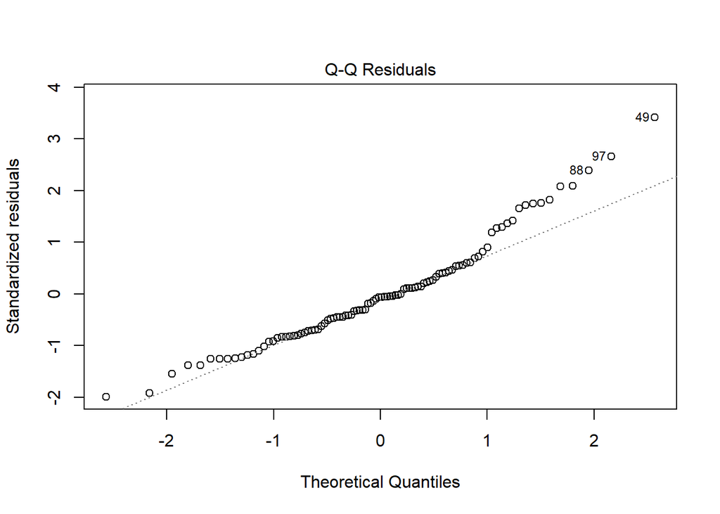

Figure 16 : graphique quantile–quantile (QQ-plot) des résidus

```r
# ==============================================================================
# DIAGNOSTICS DU MODÈLE FINAL
# ==============================================================================

# QQ-plot des résidus (normalité)
plot(modele_final, which = 2, sub.caption = "")
```

Cette conclusion est confirmée par l’examen de l’histogramme des résidus (Figure 17), qui met en évidence une distribution globalement centrée mais présentant des queues légèrement plus épaisses que celles d’une loi normale. Ainsi, si l’hypothèse de normalité est raisonnablement satisfaite pour la majorité des observations, elle semble fragilisée par le comportement des résidus les plus extrêmes.

**Code pour l’histrogramme des résidus**

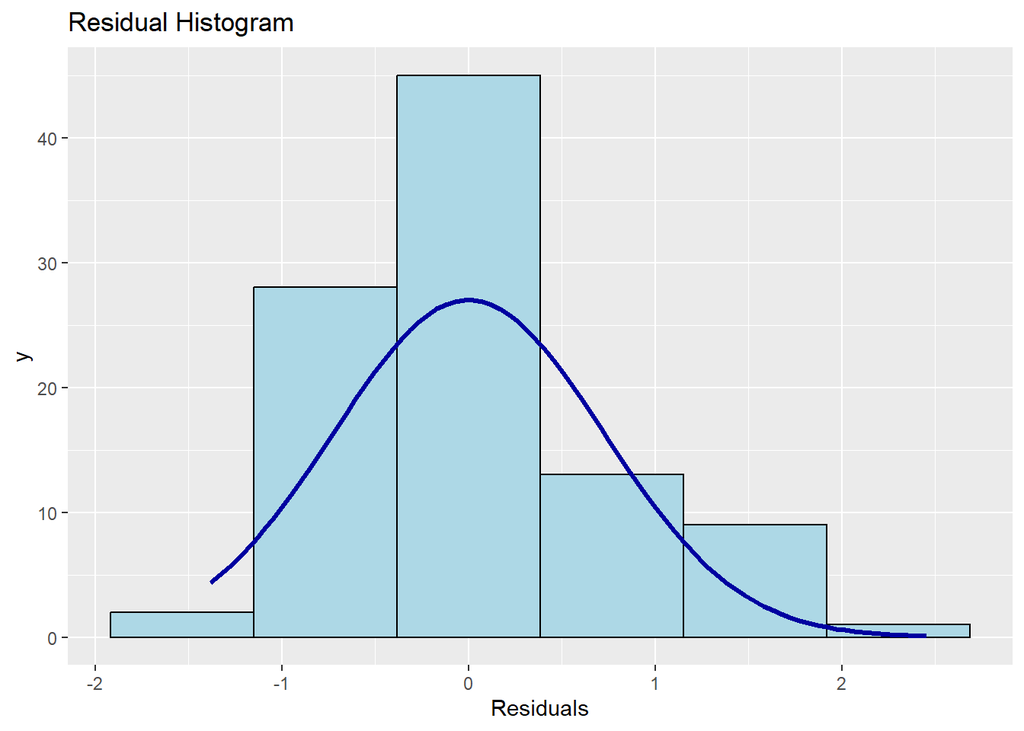

Figure 17: Histogrammes des résidus

```r
# Histogramme des résidus
ols_plot_resid_hist(modele_final)
```

### 4.2.2 Identification des observations influentes

L’identification des observations influentes permet de déterminer si certains départements exercent une influence disproportionnée sur l’estimation des coefficients. L’analyse des différents graphiques de diagnostic met en évidence trois observations problématiques, correspondant aux départements de la Lozère (49), de la Haute-Vienne (88) et de La Martinique (97). Ces départements apparaissent de manière récurrente comme s’écartant du comportement moyen des résidus, contribuant ainsi aux déviations observées par rapport à la normalité.

Le calcul de la distance de Cook (Figure 18) confirme cette observation. Trois départements se distinguent par une valeur relativement élevée de cette statistique : les départements de la Lozère (49) et de La Martinique (97), déjà identifiés précédemment, ainsi que La Mayenne (54). Ces observations présentent un potentiel d’influence non négligeable sur les estimations du modèle.

**Code pour les observations influentes (Distance de Cook)**

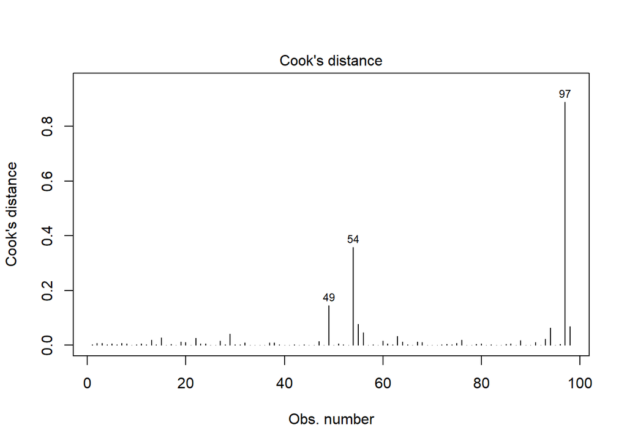

Figure 18 : Distance de Cook

```r
# Distance de Cook (observations influentes)
plot(modele_final, which = 4, sub.caption = "")
```

L’analyse du graphique des résidus standardisés en fonction du levier (Figure 19 : Residuals vs Leverage), sur lequel sont superposées les limites associées à la distance de Cook, montre que La Martinique (97) dépasse clairement les seuils critiques, ce qui indique une observation influente au sens strict. La Mayenne (54) se situe à proximité de ces seuils, sans toutefois les franchir nettement. Ces résultats suggèrent que certaines spécificités territoriales, notamment pour les départements ultramarins ou faiblement peuplés, peuvent affecter la distribution des résidus et influencer les estimations.

**Code pour les observations influentes (Résidus vs Leverage)**

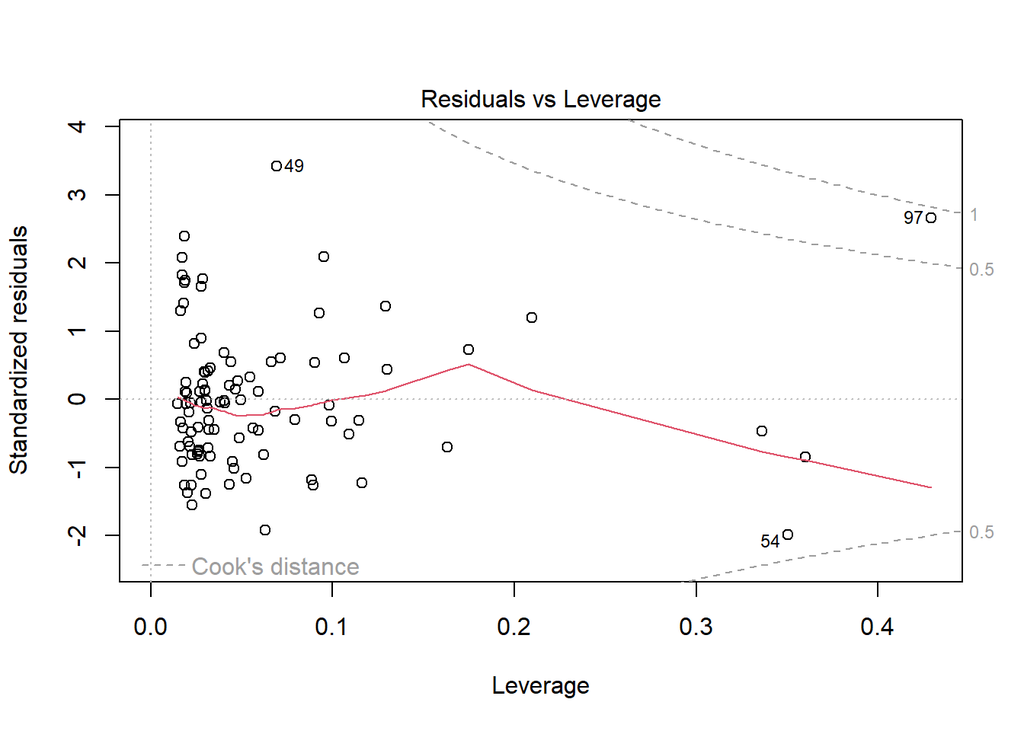

Figure 19 : Residuals vs Leverage

```r
# Résidus vs Leverage (observations influentes)
plot(modele_final, which = 5, sub.caption = "")
```

### 4.2.3 Tests de moyenne nulle et de normalité des résidus

Le modèle MCO suppose que les erreurs ont une espérance conditionnelle nulle. Cette hypothèse est testée à l’aide d’un test de Student, dont l’hypothèse nulle est $H_0 : \mathbb{E}(\epsilon_i) = 0$, contre l’alternative $H_1 :\mathbb{E}(\epsilon_i) \neq 0$.

Le test de Student appliqué aux résidus permet de vérifier l’hypothèse de moyenne nulle des erreurs. La moyenne estimée des résidus est numériquement est presque égale à zéro (=3.6×10−18) et la p-value du test est égale à 1. On ne peut donc pas rejeter l’hypothèse nulle selon laquelle l’espérance des résidus est nulle. Ce résultat est conforme aux propriétés théoriques de l’estimation par moindres carrés ordinaires en présence d’une constante.

**Code et résultats du test de moyenne nulle des résidusk**

```r
# Test de moyenne nulle des résidus
test_moyenne_nulle <- t.test(modele_final$residuals)
print(test_moyenne_nulle)
```

```
##
##  One Sample t-test
##
## data:  modele_final$residuals
## t = 4.9605e-17, df = 97, p-value = 1
## alternative hypothesis: true mean is not equal to 0
## 95 percent confidence interval:
##  -0.1450765  0.1450765
## sample estimates:
##    mean of x
## 3.625992e-18
```

La normalité des résidus est ensuite testée à l’aide du test de Shapiro–Wilk, dont l’hypothèse nulle est $H_0 : \epsilon_i \sim \mathcal{N}(0, \sigma^2)$. La p-value obtenue (0,0024) conduit à rejeter l’hypothèse de normalité. Ce résultat est cohérent avec les analyses graphiques et s’explique vraisemblablement par la présence de quelques observations extrêmes, plutôt que par une déformation générale de la distribution.

**Code et résultats du test de normalité de Shapiro-Wilk**

```r
# Test de normalité de Shapiro-Wilk
test_normalite <- shapiro.test(modele_final$residuals)
print(test_normalite)
```

```
##
##  Shapiro-Wilk normality test
##
## data:  modele_final$residuals
## W = 0.95615, p-value = 0.002447
```

Ainsi les tests confirment que l’hypothèse de moyenne nulle des résidus est vérifiée, validant ainsi une propriété clé du modèle MCO. En revanche, l’hypothèse de normalité est rejetée, probablement en raison de quelques valeurs extrêmes.

### 4.2.4 Hypothèse d’homoscedasticité

#### A) Analyse graphique de la variance des résidus

L’analyse de l’hypothèse d’homoscedasticité débute par un diagnostic graphique fondé sur le graphique Scale–Location (Figure 20), qui met en relation la racine carrée des résidus standardisés et les valeurs ajustées du modèle. Ce type de représentation permet d’identifier visuellement une éventuelle dépendance entre la dispersion des erreurs et le niveau de la variable expliquée.

En présence d’homoscedasticité, les résidus doivent être répartis de manière homogène autour d’une ligne de tendance approximativement horizontale. Dans notre cas, le graphique suggère une légère augmentation de la dispersion des résidus pour les valeurs ajustées les plus élevées, matérialisée par une inclinaison modérée de la courbe de lissage. Cette configuration pourrait indiquer une variance des erreurs légèrement croissante avec le niveau de la mortalité infantile prédite.

Toutefois, cette impression visuelle est fortement influencée par un nombre restreint d’observations atypiques, en particulier pour la Lozère (49), la Haute-Vienne (88) et sourtout pour La Martinique (97), déjà identifiés comme influents dans les diagnostics précédents. En dehors de ces points extrêmes, la majorité des observations présente une dispersion relativement stable, ce qui invite à compléter l’analyse graphique par des tests statistiques formels.

**Code et résultats pour l’analyse graphique des résidus**

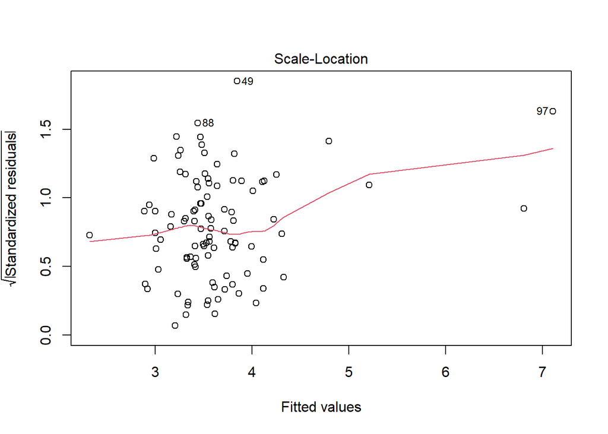

Figure 20 : Scale–Location

```r
# Scale-Location (homoscédasticité)
plot(modele_final, which = 3, sub.caption = "")
```

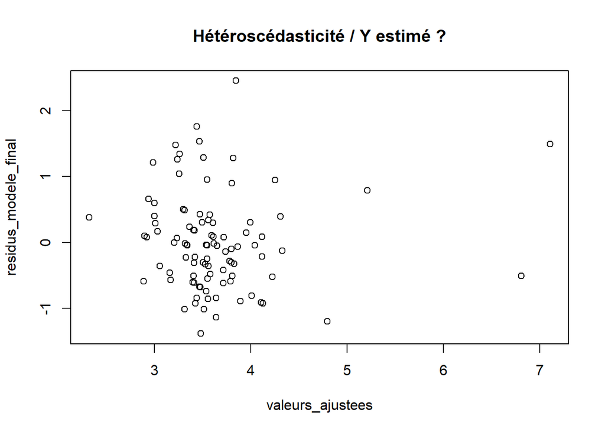

```r
# --- Graphiques d'hétéroscédasticité ---

# Extraction des résidus et valeurs ajustées
residus_modele_final <- residuals(modele_final)
residus_carres <- residus_modele_final^2
valeurs_ajustees <- fitted(modele_final)

# Résidus vs valeurs ajustées
plot(residus_modele_final ~ valeurs_ajustees,
     data = donnees_finales_avec_ind,
     main = "Hétéroscédasticité / Y estimé ?")
```

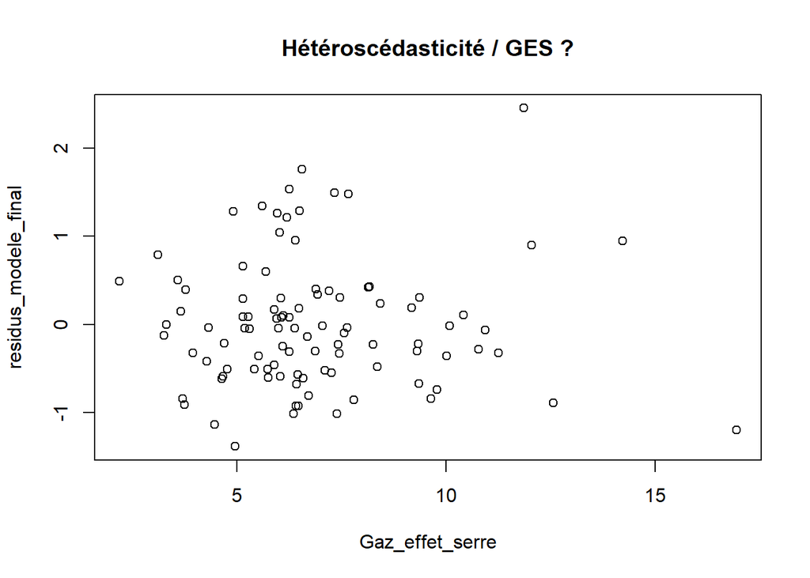

```r
# Résidus vs Gaz à effet de serre
plot(residus_modele_final ~ Gaz_effet_serre,
     data = donnees_finales_avec_ind,
     main = "Hétéroscédasticité / GES ?")
```

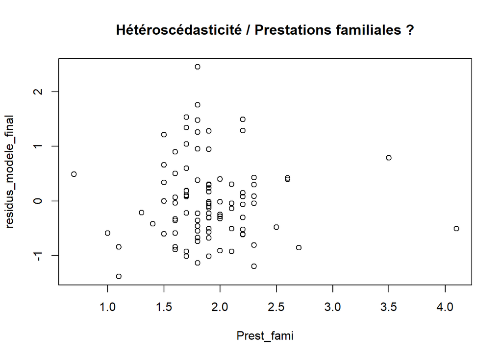

```r
# Résidus vs Prestations familiales
plot(residus_modele_final ~ Prest_fami,
     data = donnees_finales_avec_ind,
     main = "Hétéroscédasticité / Prestations familiales ?")
```

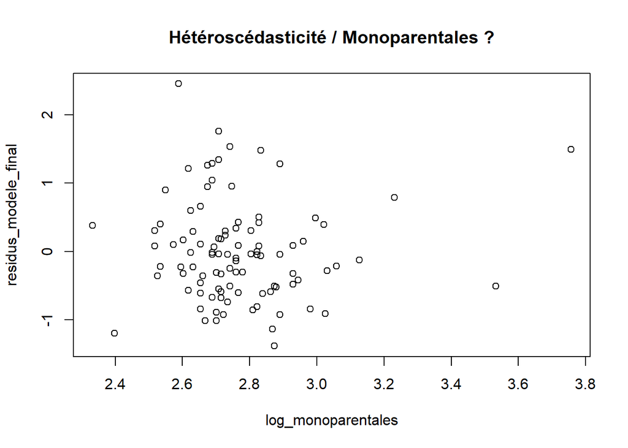

```r
# Résidus vs Part familles monoparentales
plot(residus_modele_final ~ log_monoparentales,
     data = donnees_finales_avec_ind,
     main = "Hétéroscédasticité / Monoparentales ?")
```

#### B) Analyse formelle : Tests statistiques

Afin de confirmer ou d’infirmer cette intuition visuelle, nous avons procédé à une batterie de tests formels. L’hypothèse d’homoscedasticité suppose que la variance des termes d’erreur est constante, quelle que soit la valeur des variables explicatives. Si cette hypothèse n’est pas respectée, les estimateurs MCO restent sans biais, mais les écarts-types estimés deviennent incorrects, ce qui affecte la validité des tests de Student et du test global de Fisher. Il est donc nécessaire de tester explicitement cette hypothèse à l’aide de tests formels.

On commence par le test de Breusch–Pagan, qui repose sur les hypothèses suivantes :

H₀ : la variance des résidus est constante (homoscédasticité),

H₁ : la variance des résidus dépend linéairement des variables explicatives.

Appliqué au modèle final, le test de Breusch–Pagan fournit une statistique de Breusch–Pagan égale à 8,72 pour 5 degrés de liberté, associée à une p-value de 0,1208. Cette p-value étant supérieure aux seuils de significativité, l’hypothèse nulle n’est pas rejetée. Il n’y a donc pas d’indice d’une hétéroscédasticité de forme linéaire dans le modèle.

Toutefois, le test de Breusch–Pagan est limité dans la mesure où il ne permet de détecter que des dépendances linéaires entre la variance des erreurs et les variables explicatives. Pour aller au-delà, on utilise des versions plus générales du test de White.

Cependant compte tenu de la taille limitée de l’échantillon (98 départements), un test de White complet mobilise un nombre élevé de degrés de liberté, ce qui peut réduire la puissance du test. C’est pour cette raison que un test de White restreint est également mobilisé, afin de disposer d’un diagnostic plus parcimonieux et mieux adapté aux données disponibles et que les les résultats du test de White complet doivent être interprétés avec prudence.

Ainsi le test de White restreint consiste à expliquer les carrés des résidus par les variables explicatives du modèle ainsi que par leurs carrés, sans introduire d’interactions croisées, il est de la forme suivante.

$$\begin{equation}
\begin{aligned}
\text{Test de White (restreint)} =\,& \beta_0
+ \beta_1 \, \mathrm{log\ monoparentales}_i \\
&+ \beta_2 \, \mathrm{prest\ fami}_i \\
&+ \beta_3 \, \mathrm{gaz\ effet\ serre}_i \\
&+ \beta_4 \, \mathbb{1}\!\left(\mathrm{gaz\ effet\ serre}_i >
Q_3\right) \\
&+ \beta_5 \, \mathrm{(log\ monoparentales)}_i^{2} \\
&+ \beta_6 \, \mathrm{(prest\ fami)}_i^{2} \\
&+ \beta_7 \, \mathrm{(gaz\ effet\ serre)}_i^{2}
+ \varepsilon_i
\end{aligned}
\end{equation}$$

Autrement dit, il permet de tester l’existence d’une hétéroscédasticité non linéaire, mais relativement simple, liée à l’amplitude des variables explicatives elles-mêmes. Les hypothèses testées sont les mêmes :

H₀ : homoscédasticité,

H₁ : hétéroscédasticité non linéaire.

Dans cette spécification, la statistique de Breusch–Pagan obtenue est de 8,84 avec 7 degrés de liberté, pour une p-value de 0,2646. Là encore, l’hypothèse nulle n’est pas rejetée, ce qui suggère que la variance des résidus ne dépend pas de manière quadratique des variables explicatives retenues.

Le test de White complet va encore plus loin en autorisant une forme très générale d’hétéroscédasticité. En plus des carrés des variables explicatives, il inclut l’ensemble des interactions croisées entre celles-ci, se presentant comme ceci :

$$\begin{equation}
\begin{aligned}
\text{Test de White (complet)} =\,& \beta_0
+ \beta_1 \, \big(\mathrm{log\ monoparentales}_i \times \mathrm{prest\
fami}_i\big) \\
&+ \beta_2 \, \big(\mathrm{log\ monoparentales}_i \times
\mathrm{gaz\ effet\ serre}_i\big) \\
&+ \beta_3 \, \big(\mathrm{log\ monoparentales}_i \times
\mathbb{1}\!\left(\mathrm{gaz\ effet\ serre}_i > Q_3\right)\big) \\
&+ \beta_4 \, \big(\mathrm{prest\ fami}_i \times \mathrm{gaz\ effet\
serre}_i\big) \\
&+ \beta_5 \, \big(\mathrm{prest\ fami}_i \times
\mathbb{1}\!\left(\mathrm{gaz\ effet\ serre}_i > Q_3\right)\big) \\
&+ \beta_6 \, \big(\mathrm{gaz\ effet\ serre}_i \times
\mathbb{1}\!\left(\mathrm{gaz\ effet\ serre}_i > Q_3\right)\big) \\
&+ \beta_7 \, \mathrm{(log\ monoparentales)}_i^{2} \\
&+ \beta_8 \, \mathrm{(prest\ fami)}_i^{2} \\
&+ \beta_9 \, \mathrm{(gaz\ effet\ serre)}_i^{2}
+ \varepsilon_i
\end{aligned}
\end{equation}$$

L’objectif est de détecter des structures complexes de variance conditionnelle, par exemple si la variabilité des erreurs dépend simultanément du niveau de deux variables. Ce test est volontairement large et peu parcimonieux, mais il permet de s’assurer qu’aucune forme systématique d’hétéroscédasticité n’est ignorée.

Les résultats du test de White complet indiquent une statistique de Breusch–Pagan de 10,93 pour 13 degrés de liberté, associée à une p-value de 0,6167. Cette p-value très élevée conduit clairement à ne pas rejeter l’hypothèse d’homoscedasticité, même dans une spécification extrêmement flexible.

Enfin, des tests de Goldfeld–Quandt sont réalisés afin de tester l’existence d’une hétéroscédasticité monotone, c’est-à-dire d’une variance des erreurs qui augmenterait avec le niveau d’une variable particulière. Ces tests sont appliqués successivement à la part des prestations familiales, à la part des familles monoparentales et aux émissions de gaz à effet de serre. Pour chacune de ces variables, les p-values obtenues sont largement supérieures aux seuils usuels, ce qui ne permet pas de rejeter l’hypothèse d’égalité des variances entre les sous-échantillons.

Pris dans leur ensemble, les différents tests formels conduisent à un diagnostic cohérent : aucune hétéroscédasticité statistiquement significative n’est mise en évidence dans le modèle final.

**Codes et résultats pour les différents test de l’homoscédasticité**

```r
# ==============================================================================
# TESTS D'HOMOSCÉDASTICITÉ
# ==============================================================================

# --- Test de Breusch-Pagan standard ---
test_bp_standard <- bptest(modele_final)
print(test_bp_standard)
```

```
##
##  studentized Breusch-Pagan test
##
## data:  modele_final
## BP = 8.7198, df = 5, p-value = 0.1208
```

```r
# --- Test de White restreint ---
test_white_restreint <- bptest(
  modele_final,
  ~ log_monoparentales + Prest_fami + Gaz_effet_serre + Gaz_effet_serre_Q3 +
    I(log_monoparentales^2) + I(Prest_fami^2) + I(Gaz_effet_serre^2),
  data = donnees_finales_avec_ind
)
print(test_white_restreint)
```

```
##
##  studentized Breusch-Pagan test
##
## data:  modele_final
## BP = 8.8372, df = 7, p-value = 0.2646
```

```r
# --- Test de White complet ---
test_white_complet <- bptest(
  modele_final,
  ~ log_monoparentales * Prest_fami +
    log_monoparentales * Gaz_effet_serre +
    log_monoparentales * Gaz_effet_serre_Q3 +
    Prest_fami * Gaz_effet_serre +
    Prest_fami * Gaz_effet_serre_Q3 +
    Gaz_effet_serre * Gaz_effet_serre_Q3 +
    I(log_monoparentales^2) +
    I(Prest_fami^2) +
    I(Gaz_effet_serre^2),
  data = donnees_finales_avec_ind
)
print(test_white_complet)
```

```
##
##  studentized Breusch-Pagan test
##
## data:  modele_final
## BP = 10.929, df = 13, p-value = 0.6167
```

```r
# --- Tests de Goldfeld-Quandt ---

# Test GQ pour Prestations familiales
test_gq_prest <- gqtest(modele_final,
                        order.by = ~ Prest_fami,
                        fraction = 6,
                        data = donnees_finales_avec_ind)
print(test_gq_prest)
```

```
##
##  Goldfeld-Quandt test
##
## data:  modele_final
## GQ = 0.47178, df1 = 40, df2 = 40, p-value = 0.9902
## alternative hypothesis: variance increases from segment 1 to 2
```

```r
# Test GQ pour Part familles monoparentales
test_gq_mono <- gqtest(modele_final,
                       order.by = ~ log_monoparentales,
                       fraction = 6,
                       data = donnees_finales_avec_ind)
print(test_gq_mono)
```

```
##
##  Goldfeld-Quandt test
##
## data:  modele_final
## GQ = 0.73318, df1 = 40, df2 = 40, p-value = 0.8348
## alternative hypothesis: variance increases from segment 1 to 2
```

```r
# Test GQ pour Gaz à effet de serre
test_gq_ges <- gqtest(modele_final,
                      order.by = ~ Gaz_effet_serre,
                      fraction = 6,
                      data = donnees_finales_avec_ind)
print(test_gq_ges)
```

```
##
##  Goldfeld-Quandt test
##
## data:  modele_final
## GQ = 1.4219, df1 = 40, df2 = 40, p-value = 0.1349
## alternative hypothesis: variance increases from segment 1 to 2
```

#### C) Synthèse et réconciliation du diagnostic

Les résultats obtenus peuvent donner l’impression d’une divergence entre le diagnostic graphique et les tests formels. Le graphique Scale–Location suggère en effet une possible augmentation de la dispersion des résidus pour certaines valeurs ajustées, tandis que l’ensemble des tests statistiques (Breusch–Pagan, White restreint, White complet et Goldfeld–Quandt) ne conduit pas au rejet de l’hypothèse d’homoscedasticité.

Cette différence s’explique par la nature même des outils mobilisés. Le diagnostic graphique est un outil local, très sensible aux observations extrêmes et aux points à fort levier. Dans notre cas, quelques départements atypiques, notamment la Martinique (97), exercent une influence disproportionnée sur la forme de la courbe de lissage et peuvent donner l’illusion d’une hétéroscédasticité généralisée.

À l’inverse, les tests statistiques reposent sur une évaluation globale de la structure de la variance sur l’ensemble des 98 départements. La stabilité observée pour la majorité des observations conduit logiquement à ne pas détecter un non respect de l’hypothèse d’homoscedasticité. Autrement dit, les écarts observés relèvent davantage de situations particulières que d’un problème structurel affectant l’ensemble du modèle.

#### Conclusion de la section 4.2.4

Pris dans leur ensemble, les diagnostics graphiques et les tests formels conduisent à un constat cohérent : aucune hétéroscédasticité systématique n’est mise en évidence dans le modèle final. Les légères irrégularités observées graphiquement s’expliquent principalement par la présence de quelques observations influentes plutôt que par une mauvaise spécification de la variance des erreurs.

Dans un souci de prudence méthodologique et afin de sécuriser l’inférence statistique, une estimation avec erreurs-types robustes est néanmoins présentée dans la section suivante. Cette étape permet de vérifier que les résultats du modèle ne dépendent pas de manière critique des hypothèses classiques de variance constante.

### 4.2.5 Estimation robuste à l’hétéroscédasticité

Même en l’absence d’hétéroscédasticité statistiquement significative, une estimation avec erreurs standards robustes de type White est réalisée à titre de précaution.

Cette méthode repose sur les hypothèses suivantes :

H₀ : les estimateurs MCO sont valides et les erreurs standards classiques sont correctes ;

H₁ : la variance des erreurs peut être hétéroscédastique, rendant les erreurs standards MCO non fiables.

L’estimation robuste corrige uniquement la matrice de variance-covariance des estimateurs, sans modifier les coefficients estimés. Les résultats obtenus (Figure 21) montrent que l’ensemble des coefficients conserve le même signe et des niveaux de significativité très proches de ceux présentés dans la section 4.1. Les variables centrales du modèle (la part des familles monoparentales, les émissions de gaz à effet de serre, l’indicatrice de forte pollution et le terme d’interaction associé) demeurent statistiquement significatives aux seuils usuels.

**Code pour l’estimation et la robustèce de l’hétéroscédasticité**

```r
# ==============================================================================
# ESTIMATION ROBUSTE À L'HÉTÉROSCÉDASTICITÉ
# ==============================================================================

# Calcul de la matrice de variance-covariance robuste (White HC1)
matrice_var_cov_robuste <- hccm(modele_final, type = "hc1")

# Estimation avec erreurs standard robustes
modele_final_robuste <- coeftest(modele_final, vcov = matrice_var_cov_robuste)
```

**Modèle avec coefficients et erreurs robustes**

|  | *Dependent variable:* |
| --- | --- |
|  | Mortalité Infantile |
|  | Modèle avec erreurs robustes |
| log_monoparentales | 3.244*** |
|  | (0.694) |
| Gaz_effet_serre | 0.154** |
|  | (0.064) |
| Prest_fami | 0.355* |
|  | (0.188) |
| Gaz_effet_serre_Q3 | 8.193*** |
|  | (3.017) |
| log_monoparentales:Gaz_effet_serre_Q3 | -3.174*** |
|  | (1.136) |
| Constant | -6.992*** |
|  | (2.014) |
| *Note:* | p<0.1; p<0.05; p<0.01 |

Figure 21 : Modèle avec coefficients avec erreurs robustes

Dans la mesure où l’analyse détaillée des coefficients a déjà été conduite dans la section 4.1, elle n’est pas reproduite ici. L’essentiel est que les conclusions économiques du modèle restent inchangées lorsque l’on relâche l’hypothèse d’homoscedasticité stricte.

Cette stabilité des résultats confirme la robustesse de l’inférence statistique et renforce la crédibilité des conclusions empiriques tirées du modèle final.

### 4.2.6 Conclusion de la section

Les différents diagnostics réalisés montrent que l’hypothèse de normalité des résidus n’est pas strictement vérifiée, comme l’indique le test de Shapiro–Wilk ainsi que l’analyse graphique. Cette non-normalité semble toutefois liée à la présence de quelques observations atypiques plutôt qu’à un problème général de spécification du modèle.

En revanche, les autres hypothèses du modèle des moindres carrés ordinaires apparaissent globalement satisfaites. Les tests statistiques ne mettent pas en évidence d’hétéroscédasticité significative et l’hypothèse de moyenne nulle des résidus est respectée.

La non-normalité des résidus peut, en théorie, affecter la précision des tests de significativité dans un échantillon de taille limitée. Afin de limiter ce risque, une estimation avec erreurs standards robustes a été réalisée. Les résultats obtenus confirment que les coefficients estimés et leur significativité sont très proches de ceux du modèle initial.

Dans l’ensemble, malgré cette limite liée à la distribution des résidus, les résultats du modèle apparaissent suffisamment robustes pour permettre une interprétation économique prudente.

## **4.3 Analyses complémentaires**

Cette section ne vise pas à proposer de nouvelles estimations, mais à discuter de manière critique les choix de modélisation retenus, ainsi que les limites inhérentes aux données et à la méthode employée. Elle permet d’identifier les principaux biais potentiels et d’ouvrir des pistes d’amélioration pour de futures recherches.

### 4.3.1 Transformations de variables et spécification fonctionnelle

Le modèle repose sur une spécification essentiellement linéaire, à l’exception de la transformation logarithmique de la part des familles monoparentales et de l’introduction d’une variable indicatrice pour les départements les plus pollués. Ces choix permettent une interprétation économique claire et limitent les problèmes de colinéarité.

Toutefois, cette spécification implique que les relations sont, en moyenne, linéaires à l’intérieur de chaque régime défini par le niveau de pollution. Des non-linéarités plus complexes pourraient exister, mais leur modélisation nécessiterait un échantillon plus large afin de préserver la précision des estimations.

### 4.3.2 Effets de structure et hétérogénéité non observée

L’introduction d’une variable indicatrice associée au troisième quartile des émissions de gaz à effet de serre constitue une approche simple pour capter un changement de structure entre départements faiblement et fortement pollués. Ce choix permet de mettre en évidence une hétérogénéité des relations sans recourir à des méthodes plus complexes.

Néanmoins, le seuil retenu reste en partie arbitraire et d’autres découpages de la distribution auraient pu conduire à des résultats différents. Par ailleurs, l’analyse ne permet pas d’identifier de ruptures structurelles au sens strict, celles-ci étant généralement étudiées dans des cadres temporels ou quasi-expérimentaux.

### 4.3.3 Biais de variables omises

Une limite importante du modèle tient au risque de biais de variables omises. La mortalité infantile est un phénomène multifactoriel, influencé par des déterminants médicaux, sociaux et institutionnels qui ne sont pas entièrement observables dans les données mobilisées. Parmi ces facteurs figurent notamment l’accès effectif aux soins, la densité et la qualité des infrastructures hospitalières, la disponibilité du personnel médical, ou encore certains comportements de santé liés au suivi de la grossesse et aux conditions de vie des ménages.

Ces éléments ne sont pas inclus directement dans le modèle. Or, ils peuvent varier fortement d’un département à l’autre et influencer la mortalité infantile de manière significative.

Le problème apparaît lorsque ces facteurs non observés sont liés aux variables explicatives utilisées dans le modèle. Par exemple, les départements socialement défavorisés peuvent cumuler une forte proportion de familles monoparentales, une dépendance plus élevée aux prestations sociales et un accès plus limité aux soins. Dans ce cas, l’effet estimé des variables sociales peut en partie refléter ces conditions sanitaires non observées.

Les coefficients estimés doivent donc être interprétés avec prudence. Ils décrivent des relations statistiques entre variables, mais ne permettent pas d’isoler précisément l’effet propre de chaque facteur. Les résultats mettent en évidence des associations territoriales, sans permettre de conclure à un lien causal direct.

### 4.3.4 Biais de simultanéité et endogénéité potentielle

Le modèle suppose que les variables explicatives influencent la mortalité infantile, sans que celle-ci n’ait d’effet sur ces variables. Cette hypothèse peut toutefois être discutée.

Par exemple, la part des prestations familiales sert d’indicateur de précarité. Mais il est possible que les politiques sociales augmentent ces prestations dans des départements où la mortalité infantile est plus élevée. Dans ce cas, la mortalité infantile pourrait influer sur la variable utilisée comme explicative, ce qui complique l’interprétation des résultats.

De même, certaines caractéristiques sociales comme la part des familles monoparentales peuvent être affectées par des décisions locales liées à la santé ou aux services sociaux, qui elles-mêmes réagissent à la mortalité infantile. Cela crée une relation bidirectionnelle entre la variable explicative et la mortalité infantile.

Dans ces situations, le modèle montre surtout des liens statistiques entre les variables, mais il ne permet pas de dire avec certitude que X cause Y. On ne peut donc pas interpréter ces coefficients comme des effets strictement causaux.

### 4.3.5 Erreurs de mesure et agrégation spatiale

Les variables mobilisées dans l’analyse sont mesurées au niveau départemental, ce qui implique une forte agrégation de phénomènes individuels hétérogènes. Cette agrégation peut masquer des disparités internes importantes au sein des départements, en particulier dans les territoires géographiquement étendus ou socialement contrastés.

Concernant la pollution environnementale, les émissions de gaz à effet de serre mesurées à l’échelle départementale ne reflètent qu’imparfaitement l’exposition réelle des populations, et en particulier celle des nourrissons. L’exposition effective dépend de facteurs très localisés, tels que la proximité des zones industrielles, des axes de transport ou des centres urbains, qui ne peuvent être captés par une mesure agrégée. Cette approximation peut conduire à une atténuation des effets estimés ou à une mauvaise identification des mécanismes en jeu.

De même, les variables sociales, comme la part des familles monoparentales ou des bénéficiaires de prestations familiales, ne rendent pas compte de la diversité des situations individuelles et des trajectoires de vie. Deux départements présentant des valeurs moyennes similaires peuvent ainsi recouvrir des réalités sociales très différentes, ce qui introduit une forme d’erreur de mesure.

Enfin, l’agrégation spatiale peut engendrer des biais de type « erreur écologique », dans la mesure où les relations observées au niveau départemental ne reflètent pas nécessairement les relations existant au niveau individuel. Les résultats doivent donc être interprétés comme des régularités territoriales, et non comme des comportements ou des effets observables à l’échelle des individus.

# **5 Conclusion générale et perspectives**

## 5.1 Rappel de la problématique et de la méthodologie

Ce mémoire avait pour objectif d’analyser les disparités départementales de mortalité infantile en France et d’identifier, à l’aide d’outils économétriques, les principaux déterminants socio-économiques, familiaux et environnementaux susceptibles d’expliquer les écarts observés entre territoires. La question centrale portait plus précisément sur le rôle des inégalités sociales et environnementales dans la mortalité infantile, ainsi que sur l’éventuelle hétérogénéité de leurs effets selon les caractéristiques territoriales.

Pour répondre à cette problématique, une approche économétrique fondée sur un modèle de régression linéaire estimé par les moindres carrés ordinaires a été mise en œuvre à partir de données départementales françaises. La démarche méthodologique adoptée a été volontairement progressive et rigoureuse. Elle s’est appuyée, dans un premier temps, sur une analyse descriptive approfondie des données, afin d’identifier les distributions, les valeurs extrêmes et les relations bivariées entre variables. Dans un second temps, une attention particulière a été portée à la gestion de la multicolinéarité, phénomène fréquent dans l’analyse de données territoriales, à travers l’utilisation conjointe des corrélations bivariées, de la règle de Klein et des facteurs d’inflation de la variance (VIF).

La construction du modèle final a reposé sur une combinaison de critères statistiques (critère d’information d’Akaike) et de considérations économiques, afin de parvenir à un modèle stable et interprétable. Enfin, des variables indicatrices et des termes d’interaction ont été introduits dans un objectif pédagogique et analytique, afin de tester l’existence d’effets de seuil environnementaux et d’hétérogénéités territoriales dans les relations estimées.

## 5.2 Synthèse des résultats principaux

Les résultats obtenus mettent en évidence plusieurs enseignements importants. Tout d’abord, les variables socio-économiques et familiales apparaissent comme les déterminants les plus robustes de la mortalité infantile à l’échelle départementale. En particulier, la part des familles monoparentales est fortement et positivement associée au taux de mortalité infantile, ce qui confirme l’hypothèse selon laquelle les vulnérabilités économiques et sociales constituent un facteur central des inégalités de santé dès la naissance. La part des bénéficiaires de prestations familiales est également positivement liée à la mortalité infantile, ce qui suggère que cet indicateur reflète davantage un contexte de précarité territoriale qu’un effet direct des politiques sociales sur la santé des enfants.

Les facteurs environnementaux, mesurés par les émissions de gaz à effet de serre, présentent quant à eux un effet significatif mais plus complexe. L’introduction d’une variable indicatrice associée au quartile supérieur des émissions met en évidence l’existence d’un effet de seuil, suggérant que la relation entre pollution environnementale et mortalité infantile ne peut être entièrement capturée par une spécification strictement linéaire.

Enfin, l’introduction de termes d’interaction révèle une hétérogénéité des effets selon le niveau de pollution. Le test de Chow met en évidence une différence structurelle entre les départements faiblement et fortement pollués, et l’analyse des interactions montre que l’effet de la monoparentalité sur la mortalité infantile est moins marqué dans les territoires appartenant au quartile supérieur des émissions de gaz à effet de serre. Ce résultat souligne la complexité des mécanismes à l’œuvre et suggère que les déterminants sociaux et environnementaux de la mortalité infantile interagissent de manière non triviale selon les contextes territoriaux.

## 5.3 Contributions du mémoire, apports scientifiques et/ou applicatifs

La contribution de ce travail est principalement empirique et méthodologique. Sur le plan empirique, il met en évidence l’existence de fortes disparités départementales de mortalité infantile en France et souligne le rôle central des facteurs socio-économiques et familiaux dans l’explication de ces écarts. En particulier, les résultats montrent que les territoires caractérisés par une plus grande vulnérabilité sociale présentent des niveaux de mortalité infantile plus élevés.

Sur le plan méthodologique, ce mémoire propose une application rigoureuse des outils de l’économétrie linéaire à des données territoriales hétérogènes. La démarche progressive de construction du modèle, fondée sur l’analyse descriptive, la gestion de la multicolinéarité et la sélection des variables, permet d’illustrer les arbitrages nécessaires entre qualité statistique et interprétation économique des résultats.

Enfin, d’un point de vue applicatif, les résultats suggèrent que les politiques publiques de santé infantile gagneraient à être adaptées aux spécificités territoriales, en tenant compte des inégalités sociales, familiales et environnementales. Ils rappellent que la réduction des inégalités de santé dès la naissance ne peut reposer sur des actions uniformes à l’échelle nationale.

## 5.4 Perspectives d’amélioration et de recherche future

Plusieurs limites de ce travail ouvrent des perspectives pour des recherches futures. Tout d’abord, l’analyse repose sur des données transversales, ce qui ne permet pas d’établir de relations causales. L’utilisation de données de panel permettrait d’analyser l’évolution des disparités de mortalité infantile dans le temps et de mieux contrôler l’hétérogénéité non observée entre territoires.

Ensuite, certaines dimensions importantes, notamment les facteurs médicaux et institutionnels tels que l’offre de soins, la qualité des maternités ou le suivi prénatal, n’ont pas pu être intégrées faute de données disponibles à l’échelle départementale. Leur prise en compte pourrait améliorer la compréhension des mécanismes à l’origine des écarts observés.

Par ailleurs, l’introduction d’une dimension spatiale constituerait une extension naturelle de ce travail. Des modèles économétriques spatiaux permettraient d’étudier l’existence d’effets de voisinage ou de dynamiques territoriales communes entre départements.

Enfin, le recours à des méthodes plus flexibles, intégrant des relations non linéaires, pourrait permettre d’approfondir l’analyse des effets de seuil environnementaux mis en évidence dans ce mémoire.

En définitive, ce travail constitue une première étape dans l’analyse économétrique des déterminants territoriaux de la mortalité infantile en France et ouvre la voie à des prolongements visant à mieux comprendre les inégalités de santé dès la naissance.

# **6 Bibliographie - Source des données**

## 6.1 Bibliographie

Bernard Branger, Alain Mouzard. Evolution de la mortalité infantile en France de 1900 à 2024: facteurs explicatifs sociaux, culturels, économiques et sanitaires.. Archives françaises de pédiatrie, A paraître. https://hal.science/hal-05020411v1/document

Cet article évoque les facteurs de la mortalité infantile sur la période de 1900 à 2024, malgré la dimension temporelle de cette étude, on y retrouve des facteurs explicatifs qui ne sont pas liés au temps qui nous ont permis de trouver des idées de variables explicatives.

Cette étude part du constat que la mortalité infantile a considérablement baissé depuis 1900, on identifie alors des facteurs ayant une influence sur la mortalité infantile : des facteurs sanitaires et médicaux, économiques et socio-culturels, mais depuis 2000, elle stagne, voire elle augmente on introduit alors la possibilité de l’existence d’un facteur environnemental.

Ainsi, Branger et Mouzard cherchent à expliquer la mortalité infantile par : les soins médicaux, l’alimentation des nouveaux nés, le niveau d’éducation et le milieu social des parents, les revenus des parents, l’accès au soins, l’hygiène, la pollution dans l’environnement de la femme enceinte.

Parmi ces facteurs, on peut retirer tous ceux qui présentent des caractéristiques temporelle : les épidémies, les famines, le niveau d’hygiène, le niveau de vie et d’éducation de l’époque, les avancées de la médecine, …

Il est à noter que mêmes si ces variables ne sont pas utilisables dans notre projet, on peut s’en inspirer, ainsi au lieu d’étudier la mortalité infantile en fonction du niveau de vie ou d’éducation d’une époque, on peut le faire en fonction du niveau de vie médian et de la part des diplômés selon les départements.

## 6.2 Source des données

INSEE, Obs. Territoires – BPE, CNAF, Citepa, DREES-SNIIR-AM